# Classification (Supervised Learning): Logistic Regression

Mary Solomon

2/9/2021

load the functions

```r
source("thesis_functions.R")
```

set levels of ordinal data, and other variables to their appropriate dataypes. Did not adjust the datatypes for date/time since those will not be used in this portion

```r
data <- fread("kpopdata.csv")
data <- mutate(data, ArtistType = as.factor(ArtistType),
               ArtistGender = as.factor(ArtistGender),
               ArtistGen = factor(ArtistGen),
               #release_date = as.POSIXct.Date(release_date),
               key = factor(key, levels = 0:11),
               mode = as.factor(mode),
               time_signature = factor(time_signature, levels = c(1,3,4,5)))
data$gen1 <- as.factor(ifelse(data$ArtistGen == 1, 1, 0))
data$oldgen <- as.factor(ifelse(data$ArtistGen == 1 | data$ArtistGen == 2, 1, 0))
```

Time signature is out since almost all are 4/4 time. Analysis will also be split up into logistic regression predicting for songs where mode = 0 and those for where mode = 1

Personal predictions: I believe popularity will be a strong predictor since the popularity measure is also time dependent.

# Logistic: predict which songs are old gen (1 & 2) vs new gen (3 & 4)

Create Train(70%), Valid(15%), and Test(15%) Data

```r
kpop <- select(data, oldgen, popularity, duration, acousticness, danceability, energy, instrumentalness, key, loudness, mode, speechiness, tempo, valence)
kpop0 <- kpop %>% filter(mode == 0)%>% select(-mode)
kpop1 <- kpop %>% filter(mode == 1) %>% select(-mode)

# Mode0: Train/Valid/Test
set.seed(123)
p3.0 <- partition.3(kpop0, 0.70, 0.15)
train0 <- p3.0$data.train
valid0 <- p3.0$data.val
test0 <- p3.0$data.test
all.train0 <- rbind(train0, valid0)

# Mode1: Train/Valid/Test
set.seed(123)
p3.1 <- partition.3(kpop1, 0.70, 0.15)
train1 <- p3.1$data.train
valid1 <- p3.1$data.val
test1 <- p3.1$data.test
all.train1 <- rbind(train1, valid1)
```

## Logistic Where mode = 0

Minor key

Full logistic model

```r
set.seed(123)
logit0 <- glm(oldgen ~., data = train0, family = "binomial")
summary(logit0)
```

```
##
## Call:
## glm(formula = oldgen ~ ., family = "binomial", data = train0)
##
## Deviance Residuals:
##     Min       1Q   Median       3Q      Max
## -2.4990  -0.7715   0.3725   0.7153   2.5652
##
## Coefficients:
##                   Estimate Std. Error z value Pr(>|z|)
## (Intercept)      -0.176539   0.841527  -0.210   0.8338
## popularity       -0.073492   0.002982 -24.642  < 2e-16 ***
## duration          0.535573   0.094585   5.662 1.49e-08 ***
## acousticness     -1.352971   0.310940  -4.351 1.35e-05 ***
## danceability     -0.689603   0.496092  -1.390   0.1645
## energy           -0.403242   0.546153  -0.738   0.4603
## instrumentalness -2.725461   0.613772  -4.441 8.97e-06 ***
## key1             -0.190816   0.217415  -0.878   0.3801
## key2             -0.144636   0.271669  -0.532   0.5945
## key3              0.504102   0.322027   1.565   0.1175
## key4              0.273304   0.220964   1.237   0.2161
## key5              0.189942   0.209593   0.906   0.3648
## key6              0.126234   0.216226   0.584   0.5594
## key7             -0.549019   0.236524  -2.321   0.0203 *
## key8              0.181322   0.264434   0.686   0.4929
## key9              0.291911   0.227882   1.281   0.2002
## key10             0.277182   0.231487   1.197   0.2312
## key11             0.091329   0.203465   0.449   0.6535
## loudness         -0.218762   0.038797  -5.639 1.71e-08 ***
## speechiness      -1.736218   0.713427  -2.434   0.0149 *
## tempo             0.002087   0.001884   1.108   0.2679
## valence           1.307845   0.272565   4.798 1.60e-06 ***
## ---
## Signif. codes:  0 '***' 0.001 '**' 0.01 '*' 0.05 '.' 0.1 ' ' 1
##
## (Dispersion parameter for binomial family taken to be 1)
##
##     Null deviance: 4370.7  on 3270  degrees of freedom
## Residual deviance: 3130.2  on 3249  degrees of freedom
## AIC: 3174.2
##
## Number of Fisher Scoring iterations: 5
```

find optimal cut off value

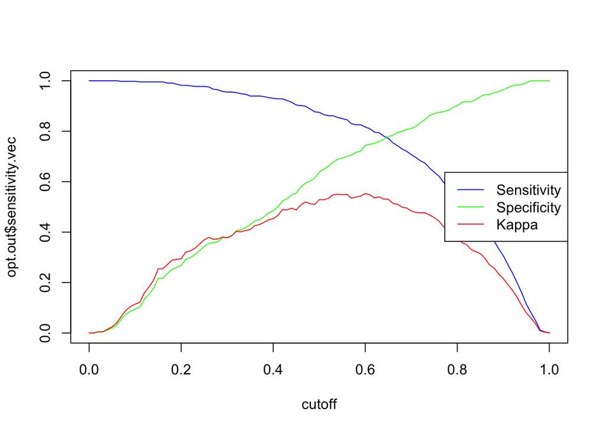

```r
logit.out0 <- opt.cut.gen(logit0, valid0)
opt.cut.plot(logit.out0)
```

```r
#optimal by kappa score
logit.out0$cutoff[which.max(logit.out0$kappa.vec)]
```

```
## [1] 0.6
```

```r
#optimal by sensitivity/specificity balance
logit.out0$cutoff[which.min(logit.out0$ssdiff.vec)]
```

```
## [1] 0.65
```

Final full logistic model fit to the combo of train and validation data.

```r
set.seed(123)
logit0.final <- glm(oldgen ~., data = all.train0, family = "binomial")
summary(logit0.final)
```

```
##
## Call:
## glm(formula = oldgen ~ ., family = "binomial", data = all.train0)
##
## Deviance Residuals:
##     Min       1Q   Median       3Q      Max
## -2.5128  -0.7632   0.3739   0.7156   2.6484
##
## Coefficients:
##                   Estimate Std. Error z value Pr(>|z|)
## (Intercept)      -0.453378   0.765547  -0.592 0.553699
## popularity       -0.073963   0.002729 -27.107  < 2e-16 ***
## duration          0.531988   0.085393   6.230 4.67e-10 ***
## acousticness     -1.279719   0.280453  -4.563 5.04e-06 ***
## danceability     -0.714916   0.455608  -1.569 0.116614
## energy           -0.227497   0.497651  -0.457 0.647569
## instrumentalness -2.789963   0.569823  -4.896 9.77e-07 ***
## key1             -0.301071   0.198782  -1.515 0.129880
## key2             -0.241643   0.247045  -0.978 0.328010
## key3              0.540052   0.296559   1.821 0.068597 .
## key4              0.307942   0.203424   1.514 0.130078
## key5              0.253116   0.193303   1.309 0.190391
## key6              0.148084   0.198377   0.746 0.455379
## key7             -0.498376   0.218746  -2.278 0.022707 *
## key8              0.194073   0.239876   0.809 0.418484
## key9              0.269600   0.208467   1.293 0.195926
## key10             0.307252   0.211239   1.455 0.145802
## key11             0.075316   0.187941   0.401 0.688608
## loudness         -0.236009   0.035790  -6.594 4.28e-11 ***
## speechiness      -2.169906   0.654692  -3.314 0.000918 ***
## tempo             0.002942   0.001710   1.720 0.085468 .
## valence           1.358594   0.248376   5.470 4.50e-08 ***
## ---
## Signif. codes:  0 '***' 0.001 '**' 0.01 '*' 0.05 '.' 0.1 ' ' 1
##
## (Dispersion parameter for binomial family taken to be 1)
##
##     Null deviance: 5290.4  on 3971  degrees of freedom
## Residual deviance: 3771.2  on 3950  degrees of freedom
## AIC: 3815.2
##
## Number of Fisher Scoring iterations: 5
```

confusion matrix on the training data:

```
logit.train0.pred <- logit0$fitted.values
logit.train0.y <- ifelse(logit.train0.pred > 0.5, 1, 0) # using cutoff = 0.5
confusionMatrix(as.factor(logit.train0.y), as.factor(train0$oldgen),
                positive = "1")
```

confusion matrix on the test data using standard cut off

```r
#get predicted probabilities for the test data
logit.test0.pred <- predict(logit0.final, newdata = test0, type = "response")
logit.test0.y <- ifelse(logit.test0.pred > 0.5, 1, 0) # using cutoff = 0.5
confusionMatrix(as.factor(logit.test0.y), as.factor(test0$oldgen),
                positive = "1")
```

```
## Confusion Matrix and Statistics
##
##           Reference
## Prediction   0   1
##          0 168  64
##          1 105 364
##
##                Accuracy : 0.7589
##                  95% CI : (0.7255, 0.7901)
##     No Information Rate : 0.6106
##     P-Value [Acc > NIR] : < 2.2e-16
##
##                   Kappa : 0.4789
##
##  Mcnemar's Test P-Value : 0.002091
##
##             Sensitivity : 0.8505
##             Specificity : 0.6154
##          Pos Pred Value : 0.7761
##          Neg Pred Value : 0.7241
##              Prevalence : 0.6106
##          Detection Rate : 0.5193
##    Detection Prevalence : 0.6690
##       Balanced Accuracy : 0.7329
##
##        'Positive' Class : 1
##
```

confusion matrix on the test data using optimal cutoff based on kappa

```r
#get predicted probabilities for the test data
logit.test0.pred <- predict(logit0.final, newdata = test0, type = "response")
logit.test0.y <- ifelse(logit.test0.pred > 0.60, 1, 0) # using cutoff = 0.60
confusionMatrix(as.factor(logit.test0.y), as.factor(test0$oldgen),
                positive = "1")
```

```
## Confusion Matrix and Statistics
##
##           Reference
## Prediction   0   1
##          0 190  96
##          1  83 332
##
##                Accuracy : 0.7447
##                  95% CI : (0.7107, 0.7766)
##     No Information Rate : 0.6106
##     P-Value [Acc > NIR] : 4.68e-14
##
##                   Kappa : 0.4676
##
##  Mcnemar's Test P-Value : 0.3698
##
##             Sensitivity : 0.7757
##             Specificity : 0.6960
##          Pos Pred Value : 0.8000
##          Neg Pred Value : 0.6643
##              Prevalence : 0.6106
##          Detection Rate : 0.4736
##    Detection Prevalence : 0.5920
##       Balanced Accuracy : 0.7358
##
##        'Positive' Class : 1
##
```

confusion matrix on the test data using optimal cutoff based on sensitivity/specificty balance

```r
#get predicted probabilities for the test data
logit.test0.pred <- predict(logit0.final, newdata = test0, type = "response")
logit.test0.y <- ifelse(logit.test0.pred > 0.65, 1, 0) # using cutoff = 0.65
confusionMatrix(as.factor(logit.test0.y), as.factor(test0$oldgen),
                positive = "1")
```

```
## Confusion Matrix and Statistics
##
##           Reference
## Prediction   0   1
##          0 195 120
##          1  78 308
##
##                Accuracy : 0.7175
##                  95% CI : (0.6826, 0.7506)
##     No Information Rate : 0.6106
##     P-Value [Acc > NIR] : 1.909e-09
##
##                   Kappa : 0.4222
##
##  Mcnemar's Test P-Value : 0.003571
##
##             Sensitivity : 0.7196
##             Specificity : 0.7143
##          Pos Pred Value : 0.7979
##          Neg Pred Value : 0.6190
##              Prevalence : 0.6106
##          Detection Rate : 0.4394
##    Detection Prevalence : 0.5506
##       Balanced Accuracy : 0.7170
##
##        'Positive' Class : 1
##
```

### Variable Selection: Stepwise

stepwise

```r
set.seed(123)
logit0.none <- glm(oldgen ~ 1, data = train0, family = binomial)
step0 <- step(logit0.none,
                 list(lower=formula(logit0.none), upper = formula(logit0)),
                 direction = "both",
                 trace=0)
formula(step0)
```

```
## oldgen ~ popularity + duration + loudness + valence + acousticness +
##     instrumentalness + key + speechiness + danceability
```

```r
summary(step0)
```

```
##
## Call:
## glm(formula = oldgen ~ popularity + duration + loudness + valence +
##     acousticness + instrumentalness + key + speechiness + danceability,
##     family = binomial, data = train0)
##
## Deviance Residuals:
##     Min       1Q   Median       3Q      Max
## -2.4937  -0.7703   0.3730   0.7193   2.5385
##
## Coefficients:
##                   Estimate Std. Error z value Pr(>|z|)
## (Intercept)      -0.253030   0.554006  -0.457   0.6479
## popularity       -0.073178   0.002942 -24.872  < 2e-16 ***
## duration          0.535828   0.094652   5.661 1.50e-08 ***
## loudness         -0.233697   0.031267  -7.474 7.76e-14 ***
## valence           1.291818   0.263451   4.903 9.42e-07 ***
## acousticness     -1.266046   0.272732  -4.642 3.45e-06 ***
## instrumentalness -2.741099   0.609355  -4.498 6.85e-06 ***
## key1             -0.183659   0.217029  -0.846   0.3974
## key2             -0.138257   0.271780  -0.509   0.6110
## key3              0.512165   0.321903   1.591   0.1116
## key4              0.269833   0.220893   1.222   0.2219
## key5              0.192689   0.209292   0.921   0.3572
## key6              0.132849   0.215687   0.616   0.5379
## key7             -0.545226   0.236436  -2.306   0.0211 *
## key8              0.183017   0.264006   0.693   0.4882
## key9              0.291443   0.227568   1.281   0.2003
## key10             0.279755   0.231273   1.210   0.2264
## key11             0.095537   0.203228   0.470   0.6383
## speechiness      -1.751742   0.699392  -2.505   0.0123 *
## danceability     -0.795588   0.476200  -1.671   0.0948 .
## ---
## Signif. codes:  0 '***' 0.001 '**' 0.01 '*' 0.05 '.' 0.1 ' ' 1
##
## (Dispersion parameter for binomial family taken to be 1)
##
##     Null deviance: 4370.7  on 3270  degrees of freedom
## Residual deviance: 3131.9  on 3251  degrees of freedom
## AIC: 3171.9
##
## Number of Fisher Scoring iterations: 5
```

find optimal cut off value

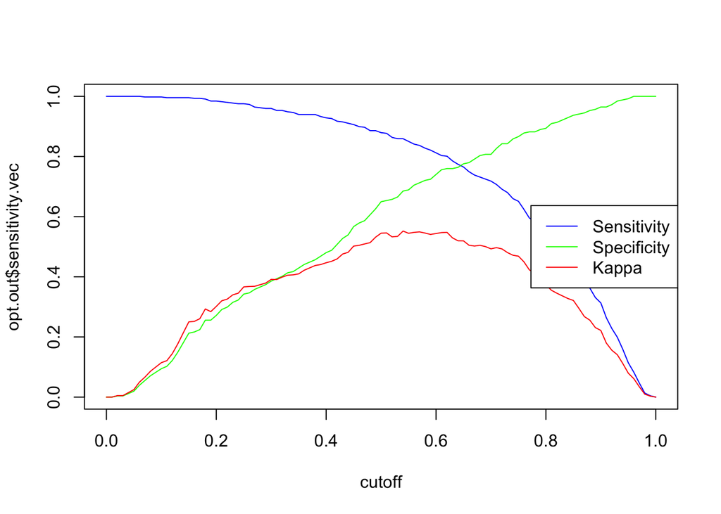

```r
step.out0 <- opt.cut.gen(step0, valid0)
opt.cut.plot(step.out0)
```

```r
#optimal by kappa score
step.out0$cutoff[which.max(step.out0$kappa.vec)]
```

```
## [1] 0.54
```

```r
#optimal by sensitivity/specificity balance
step.out0$cutoff[which.min(step.out0$ssdiff.vec)]
```

```
## [1] 0.64
```

final stepwise model

```r
set.seed(123)
logit0.none <- glm(oldgen ~ 1, data = all.train0, family = binomial)
step0.final <- step(logit0.none,
                 list(lower=formula(logit0.none), upper = formula(logit0)),
                 direction = "both",
                 trace=0)
formula(step0.final)
```

```
## oldgen ~ popularity + duration + loudness + valence + acousticness +
##     instrumentalness + key + speechiness + tempo + danceability
```

```r
summary(step0.final)
```

```
##
## Call:
## glm(formula = oldgen ~ popularity + duration + loudness + valence +
##     acousticness + instrumentalness + key + speechiness + tempo +
##     danceability, family = binomial, data = all.train0)
##
## Deviance Residuals:
##     Min       1Q   Median       3Q      Max
## -2.5168  -0.7629   0.3748   0.7136   2.6540
##
## Coefficients:
##                   Estimate Std. Error z value Pr(>|z|)
## (Intercept)      -0.684438   0.575289  -1.190 0.234153
## popularity       -0.073773   0.002695 -27.372  < 2e-16 ***
## duration          0.532244   0.085443   6.229 4.69e-10 ***
## loudness         -0.245953   0.028509  -8.627  < 2e-16 ***
## valence           1.331118   0.240965   5.524 3.31e-08 ***
## acousticness     -1.220727   0.248912  -4.904 9.38e-07 ***
## instrumentalness -2.807384   0.568985  -4.934 8.06e-07 ***
## key1             -0.297959   0.198686  -1.500 0.133705
## key2             -0.240189   0.247124  -0.972 0.331084
## key3              0.545008   0.296357   1.839 0.065911 .
## key4              0.307534   0.203471   1.511 0.130678
## key5              0.255709   0.193235   1.323 0.185735
## key6              0.152897   0.198095   0.772 0.440212
## key7             -0.497174   0.218712  -2.273 0.023015 *
## key8              0.197091   0.239737   0.822 0.411012
## key9              0.270581   0.208453   1.298 0.194272
## key10             0.309520   0.211151   1.466 0.142683
## key11             0.076322   0.187929   0.406 0.684655
## speechiness      -2.213792   0.647156  -3.421 0.000624 ***
## tempo             0.002918   0.001709   1.708 0.087679 .
## danceability     -0.694840   0.453367  -1.533 0.125369
## ---
## Signif. codes:  0 '***' 0.001 '**' 0.01 '*' 0.05 '.' 0.1 ' ' 1
##
## (Dispersion parameter for binomial family taken to be 1)
##
##     Null deviance: 5290.4  on 3971  degrees of freedom
## Residual deviance: 3771.4  on 3951  degrees of freedom
## AIC: 3813.4
##
## Number of Fisher Scoring iterations: 5
```

confusion matrix on the training data:

```
step.train0.pred <- step0$fitted.values
step.train0.y <- ifelse(step.train0.pred > 0.5, 1, 0) # using cutoff = 0.5
confusionMatrix(as.factor(step.train0.y), as.factor(train0$oldgen),
                positive = "1")
```

predict and evaluate on test using standard cut off 0.5

```r
#get predicted probabilities for the test data
step.test0.pred <- predict(step0.final, newdata = test0, type = "response")
step.test0.y <- ifelse(step.test0.pred > 0.5, 1, 0) # using cutoff = 0.5
confusionMatrix(as.factor(step.test0.y), as.factor(test0$oldgen),
                positive = "1")
```

```
## Confusion Matrix and Statistics
##
##           Reference
## Prediction   0   1
##          0 168  64
##          1 105 364
##
##                Accuracy : 0.7589
##                  95% CI : (0.7255, 0.7901)
##     No Information Rate : 0.6106
##     P-Value [Acc > NIR] : < 2.2e-16
##
##                   Kappa : 0.4789
##
##  Mcnemar's Test P-Value : 0.002091
##
##             Sensitivity : 0.8505
##             Specificity : 0.6154
##          Pos Pred Value : 0.7761
##          Neg Pred Value : 0.7241
##              Prevalence : 0.6106
##          Detection Rate : 0.5193
##    Detection Prevalence : 0.6690
##       Balanced Accuracy : 0.7329
##
##        'Positive' Class : 1
##
```

predict and evaluate on test using optimal cut off 0.54 for highest kappa

```r
#get predicted probabilities for the test data
step.test0.pred <- predict(step0.final, newdata = test0, type = "response")
step.test0.y <- ifelse(step.test0.pred > 0.54, 1, 0) # using cutoff = 0.54
confusionMatrix(as.factor(step.test0.y), as.factor(test0$oldgen),
                positive = "1")
```

```
## Confusion Matrix and Statistics
##
##           Reference
## Prediction   0   1
##          0 176  74
##          1  97 354
##
##                Accuracy : 0.7561
##                  95% CI : (0.7225, 0.7874)
##     No Information Rate : 0.6106
##     P-Value [Acc > NIR] : 2.439e-16
##
##                   Kappa : 0.4791
##
##  Mcnemar's Test P-Value : 0.09249
##
##             Sensitivity : 0.8271
##             Specificity : 0.6447
##          Pos Pred Value : 0.7849
##          Neg Pred Value : 0.7040
##              Prevalence : 0.6106
##          Detection Rate : 0.5050
##    Detection Prevalence : 0.6434
##       Balanced Accuracy : 0.7359
##
##        'Positive' Class : 1
##
```

```r
#get predicted probabilities for the test data
step.test0.pred <- predict(step0.final, newdata = test0, type = "response")
step.test0.y <- ifelse(step.test0.pred > 0.64, 1, 0) # using cutoff = 0.64
confusionMatrix(as.factor(step.test0.y), as.factor(test0$oldgen),
                positive = "1")
```

```
## Confusion Matrix and Statistics
##
##           Reference
## Prediction   0   1
##          0 194 114
##          1  79 314
##
##                Accuracy : 0.7247
##                  95% CI : (0.69, 0.7575)
##     No Information Rate : 0.6106
##     P-Value [Acc > NIR] : 1.496e-10
##
##                   Kappa : 0.4342
##
##  Mcnemar's Test P-Value : 0.01439
##
##             Sensitivity : 0.7336
##             Specificity : 0.7106
##          Pos Pred Value : 0.7990
##          Neg Pred Value : 0.6299
##              Prevalence : 0.6106
##          Detection Rate : 0.4479
##    Detection Prevalence : 0.5606
##       Balanced Accuracy : 0.7221
##
##        'Positive' Class : 1
##
```

### Variable Selection: Stepwise (10 fold CV)

step-wise 10 fold cross validation

```r
set.seed(123)
train_control <- trainControl(method = "cv",
                              number = 10)

# Fit K-fold CV model
bye <- capture.output(step0_kcv <- train(oldgen ~ ., data = train0, family = "binomial",
                 method = "glmStepAIC", trControl = train_control, verbose = FALSE))
```

```r
step0_kcv <- step0_kcv$finalModel
step0_kcv
```

```
##
## Call:  NULL
##
## Coefficients:
##      (Intercept)        popularity          duration      acousticness
##         -0.08270          -0.07302           0.53781          -1.25710
##     danceability  instrumentalness              key1              key2
##         -0.77642          -2.72978          -0.37117          -0.32620
##             key7          loudness       speechiness           valence
##         -0.73301          -0.23271          -1.75497           1.28500
##
## Degrees of Freedom: 3270 Total (i.e. Null);  3259 Residual
## Null Deviance:       4371
## Residual Deviance: 3137  AIC: 3161
```

find optimal cut off value

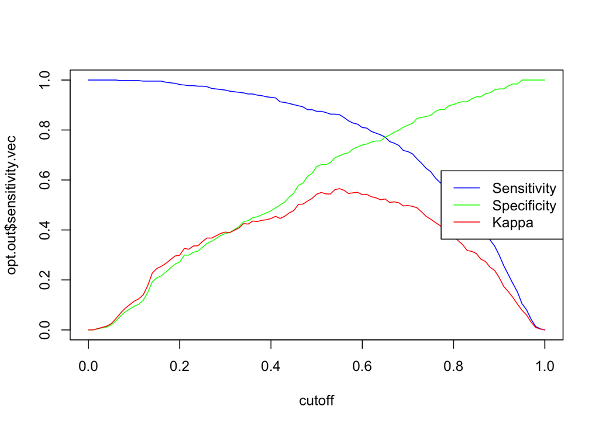

```r
step_kcv.out0 <- opt.cut.gen(step0_kcv, key.dummy(valid0))
opt.cut.plot(step_kcv.out0)
```

```r
#optimal by kappa score
step_kcv.out0$cutoff[which.max(step_kcv.out0$kappa.vec)]
```

```
## [1] 0.55
```

```r
#optimal by sensitivity/specificity balance
step_kcv.out0$cutoff[which.min(step_kcv.out0$ssdiff.vec)]
```

```
## [1] 0.65
```

Fit final model on combination of training and validation data

```r
set.seed(123)
# Fit K-fold CV model
bye2 <- capture.output(step0_kcv.final <- train(oldgen ~ ., data = all.train0, family = "binomial",
                 method = "glmStepAIC", trControl = train_control, verbose = FALSE))
```

```r
step0_kcv.final <- step0_kcv.final$finalModel
step0_kcv.final
```

```
##
## Call:  NULL
##
## Coefficients:
##      (Intercept)        popularity          duration      acousticness
##        -0.479668         -0.073599          0.531768         -1.215547
##     danceability  instrumentalness              key1              key2
##        -0.671646         -2.806627         -0.502713         -0.445063
##             key7          loudness       speechiness             tempo
##        -0.701810         -0.244850         -2.206859          0.002856
##          valence
##         1.318599
##
## Degrees of Freedom: 3971 Total (i.e. Null);  3959 Residual
## Null Deviance:       5290
## Residual Deviance: 3778  AIC: 3804
```

```
#get predicted probabilities for training data
step_kcv.train0.pred <- step0_kcv$fitted.values
step_kcv.train0.y <- ifelse(step_kcv.train0.pred > 0.5, 1, 0) # using cutoff = 0.5
confusionMatrix(as.factor(step_kcv.train0.y), as.factor(train0$oldgen),
                positive = "1")
```

Get prediction and performance evaluation for standard cut off 0.5

```r
#get predicted probabilities for the test data
step_kcv.test0.pred <- predict(step0_kcv.final, newdata = key.dummy(test0), type = "response")
step_kcv.test0.y <- ifelse(step_kcv.test0.pred > 0.5, 1, 0) # using cutoff = 0.5
confusionMatrix(as.factor(step_kcv.test0.y), as.factor(test0$oldgen),
                positive = "1")
```

```
## Confusion Matrix and Statistics
##
##           Reference
## Prediction   0   1
##          0 168  63
##          1 105 365
##
##                Accuracy : 0.7603
##                  95% CI : (0.727, 0.7915)
##     No Information Rate : 0.6106
##     P-Value [Acc > NIR] : < 2e-16
##
##                   Kappa : 0.4816
##
##  Mcnemar's Test P-Value : 0.00156
##
##             Sensitivity : 0.8528
##             Specificity : 0.6154
##          Pos Pred Value : 0.7766
##          Neg Pred Value : 0.7273
##              Prevalence : 0.6106
##          Detection Rate : 0.5207
##    Detection Prevalence : 0.6705
##       Balanced Accuracy : 0.7341
##
##        'Positive' Class : 1
##
```

Get prediction and performance evaluation for optimal cut off 0.55 for highest kappa

```r
#get predicted probabilities for the test data
step_kcv.test0.pred <- predict(step0_kcv.final, newdata = key.dummy(test0), type = "response")
step_kcv.test0.y <- ifelse(step_kcv.test0.pred > 0.55, 1, 0) # using cutoff = 0.55
confusionMatrix(as.factor(step_kcv.test0.y), as.factor(test0$oldgen),
                positive = "1")
```

```
## Confusion Matrix and Statistics
##
##           Reference
## Prediction   0   1
##          0 179  78
##          1  94 350
##
##                Accuracy : 0.7546
##                  95% CI : (0.721, 0.7861)
##     No Information Rate : 0.6106
##     P-Value [Acc > NIR] : 4.832e-16
##
##                   Kappa : 0.4785
##
##  Mcnemar's Test P-Value : 0.2527
##
##             Sensitivity : 0.8178
##             Specificity : 0.6557
##          Pos Pred Value : 0.7883
##          Neg Pred Value : 0.6965
##              Prevalence : 0.6106
##          Detection Rate : 0.4993
##    Detection Prevalence : 0.6334
##       Balanced Accuracy : 0.7367
##
##        'Positive' Class : 1
##
```

Get prediction and performance evaluation for optimal cut off 0.65 for best sensitivity/specificity balance

```r
#get predicted probabilities for the test data
step_kcv.test0.pred <- predict(step0_kcv.final, newdata = key.dummy(test0), type = "response")
step_kcv.test0.y <- ifelse(step_kcv.test0.pred > 0.65, 1, 0) # using cutoff = 0.65
confusionMatrix(as.factor(step_kcv.test0.y), as.factor(test0$oldgen),
                positive = "1")
```

```
## Confusion Matrix and Statistics
##
##           Reference
## Prediction   0   1
##          0 198 120
##          1  75 308
##
##                Accuracy : 0.7218
##                  95% CI : (0.6871, 0.7547)
##     No Information Rate : 0.6106
##     P-Value [Acc > NIR] : 4.23e-10
##
##                   Kappa : 0.432
##
##  Mcnemar's Test P-Value : 0.001628
##
##             Sensitivity : 0.7196
##             Specificity : 0.7253
##          Pos Pred Value : 0.8042
##          Neg Pred Value : 0.6226
##              Prevalence : 0.6106
##          Detection Rate : 0.4394
##    Detection Prevalence : 0.5464
##       Balanced Accuracy : 0.7225
##
##        'Positive' Class : 1
##
```

### Variable Selection: All possible regression

```r
set.seed(123)
glmulti.out0 <- glmulti(oldgen ~ ., data = train0,
                           level = 1,               # No interaction considered
            method = "h",            # Exhaustive approach
            crit = "aic",            # AIC as criteria
            confsetsize = 5,         # Keep 5 best models
            plotty = F, report = F,  # No plot or interim reports
            fitfunction = "glm",     # lm function
            family = binomial)       # binomial to run logistic regression
glmulti.out0@formulas
```

```
## [[1]]
## oldgen ~ 1 + key + popularity + duration + acousticness + danceability +
##     instrumentalness + loudness + speechiness + valence
## <environment: 0x7f867bb11c88>
##
## [[2]]
## oldgen ~ 1 + key + popularity + duration + acousticness + instrumentalness +
##     loudness + speechiness + tempo + valence
## <environment: 0x7f867bb11c88>
##
## [[3]]
## oldgen ~ 1 + key + popularity + duration + acousticness + danceability +
##     instrumentalness + loudness + speechiness + tempo + valence
## <environment: 0x7f867bb11c88>
##
## [[4]]
## oldgen ~ 1 + key + popularity + duration + acousticness + instrumentalness +
##     loudness + speechiness + valence
## <environment: 0x7f867bb11c88>
##
## [[5]]
## oldgen ~ 1 + key + popularity + duration + acousticness + danceability +
##     energy + instrumentalness + loudness + speechiness + valence
## <environment: 0x7f867bb11c88>
```

view summary of top model

```r
summary(glmulti.out0@objects[[1]])
```

```
##
## Call:
## fitfunc(formula = as.formula(x), family = ..1, data = data)
##
## Deviance Residuals:
##     Min       1Q   Median       3Q      Max
## -2.4937  -0.7703   0.3730   0.7193   2.5385
##
## Coefficients:
##                   Estimate Std. Error z value Pr(>|z|)
## (Intercept)      -0.253030   0.554006  -0.457   0.6479
## key1             -0.183659   0.217029  -0.846   0.3974
## key2             -0.138257   0.271780  -0.509   0.6110
## key3              0.512165   0.321903   1.591   0.1116
## key4              0.269833   0.220893   1.222   0.2219
## key5              0.192689   0.209292   0.921   0.3572
## key6              0.132849   0.215687   0.616   0.5379
## key7             -0.545226   0.236436  -2.306   0.0211 *
## key8              0.183017   0.264006   0.693   0.4882
## key9              0.291443   0.227568   1.281   0.2003
## key10             0.279755   0.231273   1.210   0.2264
## key11             0.095537   0.203228   0.470   0.6383
## popularity       -0.073178   0.002942 -24.872  < 2e-16 ***
## duration          0.535828   0.094652   5.661 1.50e-08 ***
## acousticness     -1.266046   0.272732  -4.642 3.45e-06 ***
## danceability     -0.795588   0.476200  -1.671   0.0948 .
## instrumentalness -2.741099   0.609355  -4.498 6.85e-06 ***
## loudness         -0.233697   0.031267  -7.474 7.76e-14 ***
## speechiness      -1.751742   0.699392  -2.505   0.0123 *
## valence           1.291818   0.263451   4.903 9.42e-07 ***
## ---
## Signif. codes:  0 '***' 0.001 '**' 0.01 '*' 0.05 '.' 0.1 ' ' 1
##
## (Dispersion parameter for binomial family taken to be 1)
##
##     Null deviance: 4370.7  on 3270  degrees of freedom
## Residual deviance: 3131.9  on 3251  degrees of freedom
## AIC: 3171.9
##
## Number of Fisher Scoring iterations: 5
```

Store model

```r
allreg.logit0 <- glmulti.out0@objects[[1]]
```

find optimal cut off value

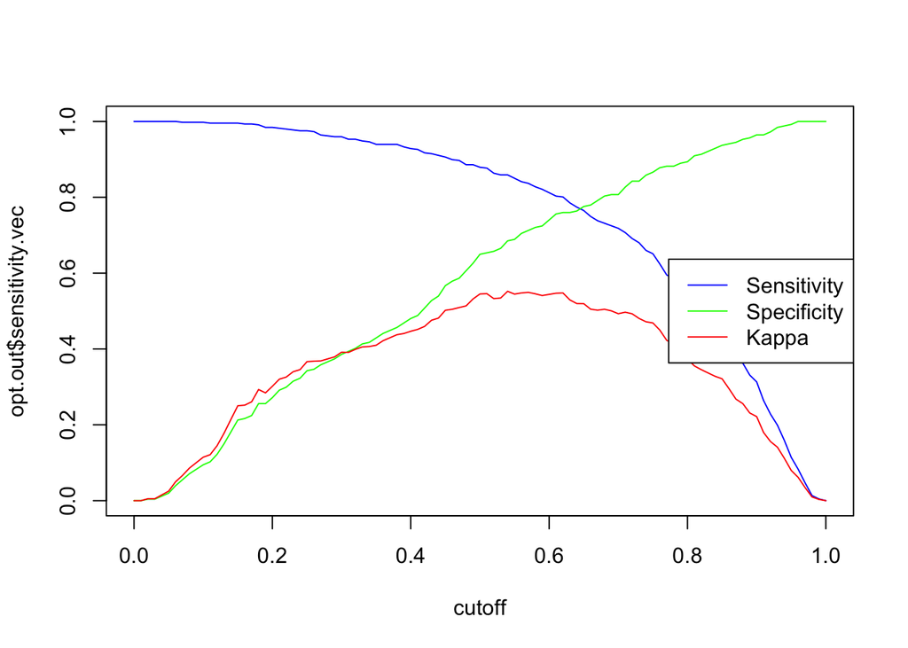

```r
allreg.out0 <- opt.cut.gen(allreg.logit0, valid0)
opt.cut.plot(allreg.out0)
```

```r
#optimal by kappa score
allreg.out0$cutoff[which.max(allreg.out0$kappa.vec)]
```

```
## [1] 0.54
```

```r
#optimal by sensitivity/specificity balance
allreg.out0$cutoff[which.min(allreg.out0$ssdiff.vec)]
```

```
## [1] 0.64
```

Fit final model on combo of train/validation data

```r
set.seed(123)
glmulti.out0.final <- glmulti(oldgen ~ ., data = all.train0,
                           level = 1,               # No interaction considered
            method = "h",            # Exhaustive approach
            crit = "aic",            # AIC as criteria
            confsetsize = 5,         # Keep 5 best models
            plotty = F, report = F,  # No plot or interim reports
            fitfunction = "glm",     # lm function
            family = binomial)       # binomial to run logistic regression
glmulti.out0.final@formulas
```

```
## [[1]]
## oldgen ~ 1 + key + popularity + duration + acousticness + danceability +
##     instrumentalness + loudness + speechiness + tempo + valence
## <environment: 0x7f869777ccc0>
##
## [[2]]
## oldgen ~ 1 + key + popularity + duration + acousticness + instrumentalness +
##     loudness + speechiness + tempo + valence
## <environment: 0x7f869777ccc0>
##
## [[3]]
## oldgen ~ 1 + key + popularity + duration + acousticness + danceability +
##     instrumentalness + loudness + speechiness + valence
## <environment: 0x7f869777ccc0>
##
## [[4]]
## oldgen ~ 1 + key + popularity + duration + acousticness + danceability +
##     energy + instrumentalness + loudness + speechiness + tempo +
##     valence
## <environment: 0x7f869777ccc0>
##
## [[5]]
## oldgen ~ 1 + key + popularity + duration + acousticness + energy +
##     instrumentalness + loudness + speechiness + tempo + valence
## <environment: 0x7f869777ccc0>
```

```r
summary(glmulti.out0.final@objects[[1]])
```

```
##
## Call:
## fitfunc(formula = as.formula(x), family = ..1, data = data)
##
## Deviance Residuals:
##     Min       1Q   Median       3Q      Max
## -2.5168  -0.7629   0.3748   0.7136   2.6540
##
## Coefficients:
##                   Estimate Std. Error z value Pr(>|z|)
## (Intercept)      -0.684438   0.575289  -1.190 0.234153
## key1             -0.297959   0.198686  -1.500 0.133705
## key2             -0.240189   0.247124  -0.972 0.331084
## key3              0.545008   0.296357   1.839 0.065911 .
## key4              0.307534   0.203471   1.511 0.130678
## key5              0.255709   0.193235   1.323 0.185735
## key6              0.152897   0.198095   0.772 0.440212
## key7             -0.497174   0.218712  -2.273 0.023015 *
## key8              0.197091   0.239737   0.822 0.411012
## key9              0.270581   0.208453   1.298 0.194272
## key10             0.309520   0.211151   1.466 0.142683
## key11             0.076322   0.187929   0.406 0.684655
## popularity       -0.073773   0.002695 -27.372  < 2e-16 ***
## duration          0.532244   0.085443   6.229 4.69e-10 ***
## acousticness     -1.220727   0.248912  -4.904 9.38e-07 ***
## danceability     -0.694840   0.453367  -1.533 0.125369
## instrumentalness -2.807384   0.568985  -4.934 8.06e-07 ***
## loudness         -0.245953   0.028509  -8.627  < 2e-16 ***
## speechiness      -2.213792   0.647156  -3.421 0.000624 ***
## tempo             0.002918   0.001709   1.708 0.087679 .
## valence           1.331118   0.240965   5.524 3.31e-08 ***
## ---
## Signif. codes:  0 '***' 0.001 '**' 0.01 '*' 0.05 '.' 0.1 ' ' 1
##
## (Dispersion parameter for binomial family taken to be 1)
##
##     Null deviance: 5290.4  on 3971  degrees of freedom
## Residual deviance: 3771.4  on 3951  degrees of freedom
## AIC: 3813.4
##
## Number of Fisher Scoring iterations: 5
```

```r
allreg.logit0.final <- glmulti.out0.final@objects[[1]]
```

try fitting training data to results from all possible regression variable selection

```
#get predicted probabilities for training data
all.train0.pred <- allreg.logit0$fitted.values
all.train0.y <- ifelse(all.train0.pred > 0.5, 1, 0) # using cutoff = 0.5
confusionMatrix(as.factor(all.train0.y), as.factor(train0$oldgen),
                positive = "1")
```

```r
#get predicted probabilities for the test data
all.test0.pred <- predict(allreg.logit0.final, newdata = test0, type = "response")
all.test0.y <- ifelse(all.test0.pred > 0.5, 1, 0) # using cutoff = 0.5
confusionMatrix(as.factor(all.test0.y), as.factor(test0$oldgen),
                positive = "1")
```

```
## Confusion Matrix and Statistics
##
##           Reference
## Prediction   0   1
##          0 168  64
##          1 105 364
##
##                Accuracy : 0.7589
##                  95% CI : (0.7255, 0.7901)
##     No Information Rate : 0.6106
##     P-Value [Acc > NIR] : < 2.2e-16
##
##                   Kappa : 0.4789
##
##  Mcnemar's Test P-Value : 0.002091
##
##             Sensitivity : 0.8505
##             Specificity : 0.6154
##          Pos Pred Value : 0.7761
##          Neg Pred Value : 0.7241
##              Prevalence : 0.6106
##          Detection Rate : 0.5193
##    Detection Prevalence : 0.6690
##       Balanced Accuracy : 0.7329
##
##        'Positive' Class : 1
##
```

```r
#get predicted probabilities for the test data
all.test0.pred <- predict(allreg.logit0.final, newdata = test0, type = "response")
all.test0.y <- ifelse(all.test0.pred > 0.54, 1, 0) # using cutoff = 0.54
confusionMatrix(as.factor(all.test0.y), as.factor(test0$oldgen),
                positive = "1")
```

```
## Confusion Matrix and Statistics
##
##           Reference
## Prediction   0   1
##          0 176  74
##          1  97 354
##
##                Accuracy : 0.7561
##                  95% CI : (0.7225, 0.7874)
##     No Information Rate : 0.6106
##     P-Value [Acc > NIR] : 2.439e-16
##
##                   Kappa : 0.4791
##
##  Mcnemar's Test P-Value : 0.09249
##
##             Sensitivity : 0.8271
##             Specificity : 0.6447
##          Pos Pred Value : 0.7849
##          Neg Pred Value : 0.7040
##              Prevalence : 0.6106
##          Detection Rate : 0.5050
##    Detection Prevalence : 0.6434
##       Balanced Accuracy : 0.7359
##
##        'Positive' Class : 1
##
```

```r
#get predicted probabilities for the test data
all.test0.pred <- predict(allreg.logit0.final, newdata = test0, type = "response")
all.test0.y <- ifelse(all.test0.pred > 0.64, 1, 0) # using cutoff = 0.64
confusionMatrix(as.factor(all.test0.y), as.factor(test0$oldgen),
                positive = "1")
```

```
## Confusion Matrix and Statistics
##
##           Reference
## Prediction   0   1
##          0 194 114
##          1  79 314
##
##                Accuracy : 0.7247
##                  95% CI : (0.69, 0.7575)
##     No Information Rate : 0.6106
##     P-Value [Acc > NIR] : 1.496e-10
##
##                   Kappa : 0.4342
##
##  Mcnemar's Test P-Value : 0.01439
##
##             Sensitivity : 0.7336
##             Specificity : 0.7106
##          Pos Pred Value : 0.7990
##          Neg Pred Value : 0.6299
##              Prevalence : 0.6106
##          Detection Rate : 0.4479
##    Detection Prevalence : 0.5606
##       Balanced Accuracy : 0.7221
##
##        'Positive' Class : 1
##
```

### Regularized Regression: Ridge 10 fold Cross Validation

```r
set.seed(123)
ridge0 <- train(oldgen ~ ., data = train0, method = "glmnet",
                      family = "binomial", trControl = train_control,
                      tuneGrid = expand.grid(alpha = 0,lambda = seq(0.001,0.1,by = 0.001)))
#best tuning parameter
ridge0$bestTune
```

```
##    alpha lambda
## 26     0  0.026
```

```r
ridge0.model <- coef(ridge0$finalModel, ridge0$bestTune$lambda)
ridge0.model
```

```
## 22 x 1 sparse Matrix of class "dgCMatrix"
##                             1
## (Intercept)      -0.342986785
## popularity       -0.059739173
## duration          0.458008683
## acousticness     -0.943037795
## danceability     -0.253321254
## energy           -0.226537570
## instrumentalness -1.829317116
## key1             -0.200329846
## key2             -0.163034630
## key3              0.320924196
## key4              0.183529157
## key5              0.090452867
## key6              0.034752211
## key7             -0.490783381
## key8              0.117748767
## key9              0.185618936
## key10             0.170964353
## key11             0.040852131
## loudness         -0.167316344
## speechiness      -1.472352509
## tempo             0.001789999
## valence           0.979653827
```

Search for best cutoff using validation set

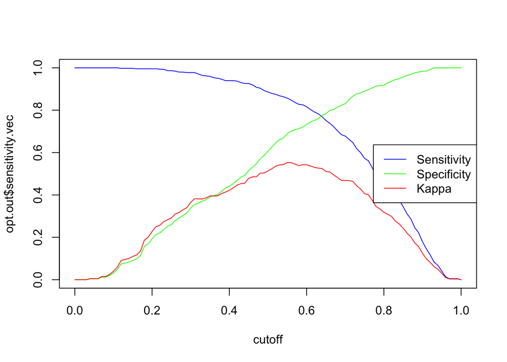

```r
ridge0.out <- reg.opt.cut.gen(ridge0, valid0)
opt.cut.plot(ridge0.out)
```

```r
# cut off by kappa
ridge0.out$cutoff[which.max(ridge0.out$kappa.vec)]
```

```
## [1] 0.55
```

```r
ridge0.out$cutoff[which.min(ridge0.out$ssdiff.vec)]
```

```
## [1] 0.64
```

create final model

```r
set.seed(123)
ridge0.final <- train(oldgen ~ ., data = all.train0, method = "glmnet",
                      family = "binomial", trControl = train_control,
                      tuneGrid = expand.grid(alpha = 0,lambda = seq(0.001,0.1,by = 0.001)))
#best tuning parameter
ridge0.final$bestTune
```

```
##    alpha lambda
## 30     0   0.03
```

```r
ridge0.model.final <- coef(ridge0.final$finalModel, ridge0.final$bestTune$lambda)
ridge0.model.final
```

```
## 22 x 1 sparse Matrix of class "dgCMatrix"
##                             1
## (Intercept)      -0.459039054
## popularity       -0.058856235
## duration          0.447956855
## acousticness     -0.877390392
## danceability     -0.255046297
## energy           -0.153259546
## instrumentalness -1.771403023
## key1             -0.284157745
## key2             -0.232415065
## key3              0.347728688
## key4              0.196945088
## key5              0.131949109
## key6              0.043405007
## key7             -0.437843671
## key8              0.117865891
## key9              0.173028005
## key10             0.185933793
## key11             0.029951882
## loudness         -0.170820422
## speechiness      -1.740199508
## tempo             0.002283353
## valence           0.997220833
```

predict and evaluate on the test set where cutoff is at 0.5

```r
prob.ridge0 <- predict(ridge0.final, s = ridge0.final$bestTune, test0, type = "prob")
pred.ridge0 <- ifelse(prob.ridge0[,2] > 0.50, 1, 0) # using cutoff = 0.5
confusionMatrix(as.factor(pred.ridge0), as.factor(test0$oldgen),
                positive = "1")
```

```
## Confusion Matrix and Statistics
##
##           Reference
## Prediction   0   1
##          0 163  60
##          1 110 368
##
##                Accuracy : 0.7575
##                  95% CI : (0.724, 0.7888)
##     No Information Rate : 0.6106
##     P-Value [Acc > NIR] : < 2.2e-16
##
##                   Kappa : 0.4726
##
##  Mcnemar's Test P-Value : 0.0001712
##
##             Sensitivity : 0.8598
##             Specificity : 0.5971
##          Pos Pred Value : 0.7699
##          Neg Pred Value : 0.7309
##              Prevalence : 0.6106
##          Detection Rate : 0.5250
##    Detection Prevalence : 0.6819
##       Balanced Accuracy : 0.7284
##
##        'Positive' Class : 1
##
```

predict and evaluate on the test set where cutoff is at 0.55 corresponding to optimal kappa

```r
prob.ridge0 <- predict(ridge0.final, s = ridge0.final$bestTune, test0, type = "prob")
pred.ridge0 <- ifelse(prob.ridge0[,2] > 0.55, 1, 0) # using cutoff = 0.55
confusionMatrix(as.factor(pred.ridge0), as.factor(test0$oldgen),
                positive = "1")
```

```
## Confusion Matrix and Statistics
##
##           Reference
## Prediction   0   1
##          0 180  73
##          1  93 355
##
##                Accuracy : 0.7632
##                  95% CI : (0.7299, 0.7942)
##     No Information Rate : 0.6106
##     P-Value [Acc > NIR] : <2e-16
##
##                   Kappa : 0.4954
##
##  Mcnemar's Test P-Value : 0.1403
##
##             Sensitivity : 0.8294
##             Specificity : 0.6593
##          Pos Pred Value : 0.7924
##          Neg Pred Value : 0.7115
##              Prevalence : 0.6106
##          Detection Rate : 0.5064
##    Detection Prevalence : 0.6391
##       Balanced Accuracy : 0.7444
##
##        'Positive' Class : 1
##
```

predict and evaluate on the test set where cutoff is at 0.64 corresponding to optimal balance of sensitivity and specificity

```r
prob.ridge0 <- predict(ridge0.final, s = ridge0.final$bestTune, test0, type = "prob")
pred.ridge0 <- ifelse(prob.ridge0[,2] > 0.64, 1, 0) # using cutoff = 0.64
confusionMatrix(as.factor(pred.ridge0), as.factor(test0$oldgen),
                positive = "1")
```

```
## Confusion Matrix and Statistics
##
##           Reference
## Prediction   0   1
##          0 195 117
##          1  78 311
##
##                Accuracy : 0.7218
##                  95% CI : (0.6871, 0.7547)
##     No Information Rate : 0.6106
##     P-Value [Acc > NIR] : 4.23e-10
##
##                   Kappa : 0.4298
##
##  Mcnemar's Test P-Value : 0.006504
##
##             Sensitivity : 0.7266
##             Specificity : 0.7143
##          Pos Pred Value : 0.7995
##          Neg Pred Value : 0.6250
##              Prevalence : 0.6106
##          Detection Rate : 0.4437
##    Detection Prevalence : 0.5549
##       Balanced Accuracy : 0.7205
##
##        'Positive' Class : 1
##
```

### Regularized Regression: Lasso 10 fold Cross Validation

```r
set.seed(123)
lasso0 <- train(oldgen ~ ., data = train0, method = "glmnet",
                      family = "binomial", trControl = train_control,
                      tuneGrid = expand.grid(alpha = 1,lambda = seq(0.001,0.1,by = 0.001)))
# best parameter
lasso0$bestTune
```

```
##   alpha lambda
## 3     1  0.003
```

```r
# best coefficient
lasso0.model <- coef(lasso0$finalModel, lasso0$bestTune$lambda)
lasso0.model
```

```
## 22 x 1 sparse Matrix of class "dgCMatrix"
##                             1
## (Intercept)      -0.341293529
## popularity       -0.071443674
## duration          0.498541843
## acousticness     -1.013277493
## danceability     -0.233727374
## energy           -0.027268175
## instrumentalness -2.298452027
## key1             -0.254421007
## key2             -0.181597746
## key3              0.260021859
## key4              0.066894362
## key5              0.006803417
## key6              .
## key7             -0.595499688
## key8              .
## key9              0.087084456
## key10             0.075764875
## key11             .
## loudness         -0.199807544
## speechiness      -1.362468732
## tempo             0.001378005
## valence           1.025495352
```

Search for best cutoff using validation set

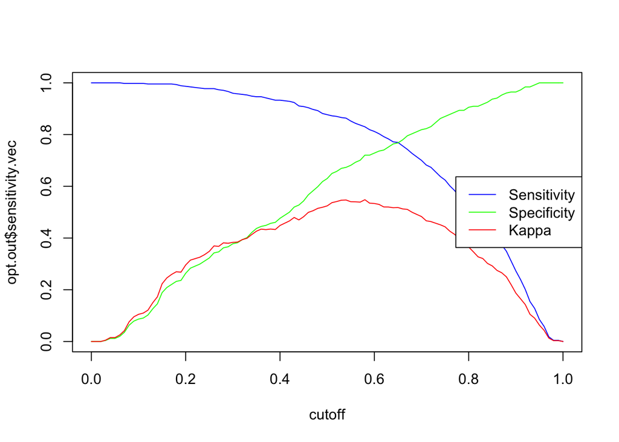

```r
lasso0.out <- reg.opt.cut.gen(lasso0, valid0)
opt.cut.plot(lasso0.out)
```

```r
# cut off by kappa
lasso0.out$cutoff[which.max(lasso0.out$kappa.vec)]
```

```
## [1] 0.58
```

```r
lasso0.out$cutoff[which.min(lasso0.out$ssdiff.vec)]
```

```
## [1] 0.65
```

create final model

```r
set.seed(123)
lasso0.final <- train(oldgen ~ ., data = train0, method = "glmnet",
                      family = "binomial", trControl = train_control,
                      tuneGrid = expand.grid(alpha = 1,lambda = seq(0.001,0.1,by = 0.001)))
# best parameter
lasso0.final$bestTune
```

```
##   alpha lambda
## 3     1  0.003
```

```r
# best coefficient
lasso0.model.final <- coef(lasso0.final$finalModel, lasso0.final$bestTune$lambda)
lasso0.model.final
```

```
## 22 x 1 sparse Matrix of class "dgCMatrix"
##                             1
## (Intercept)      -0.341293529
## popularity       -0.071443674
## duration          0.498541843
## acousticness     -1.013277493
## danceability     -0.233727374
## energy           -0.027268175
## instrumentalness -2.298452027
## key1             -0.254421007
## key2             -0.181597746
## key3              0.260021859
## key4              0.066894362
## key5              0.006803417
## key6              .
## key7             -0.595499688
## key8              .
## key9              0.087084456
## key10             0.075764875
## key11             .
## loudness         -0.199807544
## speechiness      -1.362468732
## tempo             0.001378005
## valence           1.025495352
```

predict and evaluate on the test set where cutoff is at 0.5

```r
prob.lasso0 <- predict(lasso0.final, s = lasso0.final$bestTune, test0, type = "prob")
pred.lasso0 <- ifelse(prob.lasso0[,2] > 0.50, 1, 0) # using cutoff = 0.5
confusionMatrix(as.factor(pred.lasso0), as.factor(test0$oldgen),
                positive = "1")
```

```
## Confusion Matrix and Statistics
##
##           Reference
## Prediction   0   1
##          0 166  61
##          1 107 367
##
##                Accuracy : 0.7603
##                  95% CI : (0.727, 0.7915)
##     No Information Rate : 0.6106
##     P-Value [Acc > NIR] : < 2.2e-16
##
##                   Kappa : 0.4802
##
##  Mcnemar's Test P-Value : 0.0005169
##
##             Sensitivity : 0.8575
##             Specificity : 0.6081
##          Pos Pred Value : 0.7743
##          Neg Pred Value : 0.7313
##              Prevalence : 0.6106
##          Detection Rate : 0.5235
##    Detection Prevalence : 0.6762
##       Balanced Accuracy : 0.7328
##
##        'Positive' Class : 1
##
```

predict and evaluate on the test set where cutoff is at 0.58 corresponding to optimal kappa

```r
prob.lasso0 <- predict(lasso0.final, s = lasso0.final$bestTune, test0, type = "prob")
pred.lasso0 <- ifelse(prob.lasso0[,2] > 0.58, 1, 0) # using cutoff = 0.58
confusionMatrix(as.factor(pred.lasso0), as.factor(test0$oldgen),
                positive = "1")
```

```
## Confusion Matrix and Statistics
##
##           Reference
## Prediction   0   1
##          0 186  87
##          1  87 341
##
##                Accuracy : 0.7518
##                  95% CI : (0.7181, 0.7834)
##     No Information Rate : 0.6106
##     P-Value [Acc > NIR] : 1.853e-15
##
##                   Kappa : 0.478
##
##  Mcnemar's Test P-Value : 1
##
##             Sensitivity : 0.7967
##             Specificity : 0.6813
##          Pos Pred Value : 0.7967
##          Neg Pred Value : 0.6813
##              Prevalence : 0.6106
##          Detection Rate : 0.4864
##    Detection Prevalence : 0.6106
##       Balanced Accuracy : 0.7390
##
##        'Positive' Class : 1
##
```

predict and evaluate on the test set where cutoff is at 0.65 corresponding to optimal balance of sensitivity and specificity

```r
prob.lasso0 <- predict(lasso0.final, s = lasso0.final$bestTune, test0, type = "prob")
pred.lasso0 <- ifelse(prob.lasso0[,2] > 0.65, 1, 0) # using cutoff = 0.65
confusionMatrix(as.factor(pred.lasso0), as.factor(test0$oldgen),
                positive = "1")
```

```
## Confusion Matrix and Statistics
##
##           Reference
## Prediction   0   1
##          0 199 116
##          1  74 312
##
##                Accuracy : 0.729
##                  95% CI : (0.6944, 0.7616)
##     No Information Rate : 0.6106
##     P-Value [Acc > NIR] : 2.987e-11
##
##                   Kappa : 0.4455
##
##  Mcnemar's Test P-Value : 0.002935
##
##             Sensitivity : 0.7290
##             Specificity : 0.7289
##          Pos Pred Value : 0.8083
##          Neg Pred Value : 0.6317
##              Prevalence : 0.6106
##          Detection Rate : 0.4451
##    Detection Prevalence : 0.5506
##       Balanced Accuracy : 0.7290
##
##        'Positive' Class : 1
##
```

### Regularized Regression: Elastic Net 10 fold Cross Validation

```r
set.seed(123)
enet0 <- train(oldgen ~ ., data = train0, method = "glmnet",
                      family = "binomial", trControl = train_control,
                      tuneGrid = expand.grid(alpha = seq(0,1,by = 0.05),lambda = seq(0.001,0.1,by = 0.001)))
# best parameter
enet0$bestTune
```

```
##      alpha lambda
## 1405   0.7  0.005
```

```r
# best coefficient
enet0.model <- coef(enet0$finalModel, enet0$bestTune$lambda)
enet0.model
```

```
## 22 x 1 sparse Matrix of class "dgCMatrix"
##                            1
## (Intercept)      -0.35838417
## popularity       -0.07021887
## duration          0.48777303
## acousticness     -0.94759673
## danceability     -0.14075600
## energy            .
## instrumentalness -2.16638540
## key1             -0.24305425
## key2             -0.16662001
## key3              0.23287462
## key4              0.05275183
## key5              .
## key6              .
## key7             -0.57661058
## key8              .
## key9              0.07191545
## key10             0.06033519
## key11             .
## loudness         -0.19178537
## speechiness      -1.28084710
## tempo             0.00126279
## valence           0.96651453
```

search for best cutoff with validation set

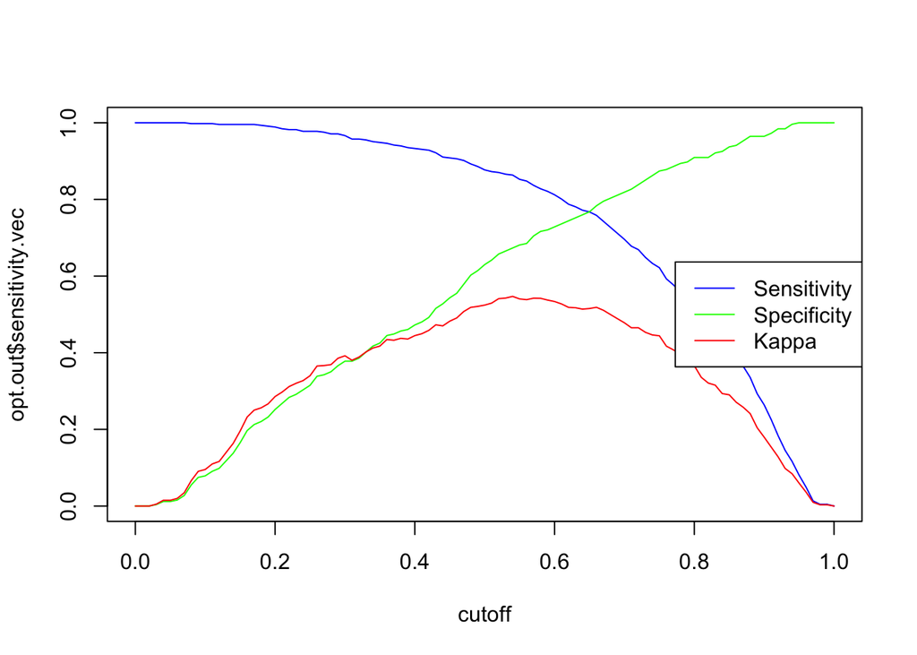

```r
enet0.out <- reg.opt.cut.gen(enet0, valid0)
opt.cut.plot(enet0.out)
```

```r
# cut off by kappa
enet0.out$cutoff[which.max(enet0.out$kappa.vec)]
```

```
## [1] 0.54
```

```r
enet0.out$cutoff[which.min(enet0.out$ssdiff.vec)]
```

```
## [1] 0.65
```

create final model on train and validation

```r
set.seed(123)
enet0.final <- train(oldgen ~ ., data = all.train0, method = "glmnet",
                      family = "binomial", trControl = train_control,
                      tuneGrid = expand.grid(alpha = seq(0,1,by = 0.05),lambda = seq(0.001,0.1,by = 0.001)))
# best parameter
enet0.final$bestTune
```

```
##     alpha lambda
## 508  0.25  0.008
```

```r
# best coefficient
enet0.model.final <- coef(enet0.final$finalModel, enet0.final$bestTune$lambda)
enet0.model.final
```

```
## 22 x 1 sparse Matrix of class "dgCMatrix"
##                             1
## (Intercept)      -0.503738344
## popularity       -0.068720764
## duration          0.486688318
## acousticness     -0.974160392
## danceability     -0.297677248
## energy           -0.005415829
## instrumentalness -2.239758398
## key1             -0.352548328
## key2             -0.275847790
## key3              0.319522257
## key4              0.129259523
## key5              0.086195364
## key6              .
## key7             -0.525596233
## key8              0.026128539
## key9              0.102726564
## key10             0.131027338
## key11            -0.004034894
## loudness         -0.204675211
## speechiness      -1.789246057
## tempo             0.002262606
## valence           1.085713448
```

predict and evaluate on the test set where cutoff is at 0.5

```r
prob.enet0 <- predict(enet0.final, s = enet0.final$bestTune, test0, type = "prob")
pred.enet0 <- ifelse(prob.enet0[,2] > 0.50, 1, 0) # using cutoff = 0.5
confusionMatrix(as.factor(pred.enet0), as.factor(test0$oldgen),
                positive = "1")
```

```
## Confusion Matrix and Statistics
##
##           Reference
## Prediction   0   1
##          0 167  63
##          1 106 365
##
##                Accuracy : 0.7589
##                  95% CI : (0.7255, 0.7901)
##     No Information Rate : 0.6106
##     P-Value [Acc > NIR] : < 2.2e-16
##
##                   Kappa : 0.4782
##
##  Mcnemar's Test P-Value : 0.001235
##
##             Sensitivity : 0.8528
##             Specificity : 0.6117
##          Pos Pred Value : 0.7749
##          Neg Pred Value : 0.7261
##              Prevalence : 0.6106
##          Detection Rate : 0.5207
##    Detection Prevalence : 0.6719
##       Balanced Accuracy : 0.7323
##
##        'Positive' Class : 1
##
```

predict and evaluate on the test set where cutoff is at 0.54 corresponding to optimal kappa

```r
prob.enet0 <- predict(enet0.final, s = enet0.final$bestTune, test0, type = "prob")
pred.enet0 <- ifelse(prob.enet0[,2] > 0.54, 1, 0) # using cutoff = 0.54
confusionMatrix(as.factor(pred.enet0), as.factor(test0$oldgen),
                positive = "1")
```

```
## Confusion Matrix and Statistics
##
##           Reference
## Prediction   0   1
##          0 178  73
##          1  95 355
##
##                Accuracy : 0.7603
##                  95% CI : (0.727, 0.7915)
##     No Information Rate : 0.6106
##     P-Value [Acc > NIR] : <2e-16
##
##                   Kappa : 0.4886
##
##  Mcnemar's Test P-Value : 0.1052
##
##             Sensitivity : 0.8294
##             Specificity : 0.6520
##          Pos Pred Value : 0.7889
##          Neg Pred Value : 0.7092
##              Prevalence : 0.6106
##          Detection Rate : 0.5064
##    Detection Prevalence : 0.6419
##       Balanced Accuracy : 0.7407
##
##        'Positive' Class : 1
##
```

predict and evaluate on the test set where cutoff is at 0.65 corresponding to optimal balance of sensitivity and specificity

```r
prob.enet0 <- predict(enet0.final, s = enet0.final$bestTune, test0, type = "prob")
pred.enet0 <- ifelse(prob.enet0[,2] > 0.65, 1, 0) # using cutoff = 0.65
confusionMatrix(as.factor(pred.enet0), as.factor(test0$oldgen),
                positive = "1")
```

```
## Confusion Matrix and Statistics
##
##           Reference
## Prediction   0   1
##          0 199 119
##          1  74 309
##
##                Accuracy : 0.7247
##                  95% CI : (0.69, 0.7575)
##     No Information Rate : 0.6106
##     P-Value [Acc > NIR] : 1.496e-10
##
##                   Kappa : 0.4378
##
##  Mcnemar's Test P-Value : 0.001539
##
##             Sensitivity : 0.7220
##             Specificity : 0.7289
##          Pos Pred Value : 0.8068
##          Neg Pred Value : 0.6258
##              Prevalence : 0.6106
##          Detection Rate : 0.4408
##    Detection Prevalence : 0.5464
##       Balanced Accuracy : 0.7255
##
##        'Positive' Class : 1
##
```

### Deciding on the best model for Mode 0 songs

Full Logistic model
$$log(\frac{\hat \pi}{1 - \hat \pi}) = -0.453 - 0.074x_{Popularity} + 0.532x_{Duration} - 1.280x_{Acousticness} - 0.715x_{Danceability}
\\ - 0.227x_{Energy} - 2.790x_{Instrumentalness} - 0.301x_{Key1} - 0.242x_{Key2}
\\ + 0.540x_{Key3} + 0.308x_{Key4} + 0.253x_{Key5} + 0.148x_{Key6} - 0.498x_{Key7}
\\ + 0.194x_{Key8} + 0.270x_{Key9} + 0.307x_{Key10} + 0.075x_{Key11} - 0.236x_{Loudness}
\\ -2.170x_{Speechiness} + 0.003x_{Tempo} + 1.359x_{Valence}$$

All Possible Regressions Model Compared to the full model, Energy is not included in this model
$$log(\frac{\hat \pi}{1 - \hat \pi}) = -0.684 - 0.074x_{Popularity} + 0.532x_{Duration} - 1.221x_{Acousticness}
\\ -0.695_{Duration} - 2.807x_{Instrumentalness} - 0.298x_{Key1} - 0.240x_{Key2}
\\ + 0.545x_{Key3} + 0.308x_{Key4} + 0.256x_{Key5} + 0.153x_{Key6} - 0.497x_{Key7}
\\ + 0.197x_{Key8} + 0.271x_{Key9} + 0.310x_{Key10} + 0.076x_{Key11} - 0.245x_{Loudness}
\\ -2.214x_{Speechiness} + 0.003x_{Tempo} + 1.331x_{Valence}$$

Ridge 10 fold Cross Validation model
$$log(\frac{\hat \pi}{1 - \hat \pi}) = -0.343 - 0.060{Popularity} + 0.458{Duration} - 0.943{Acousticness} - 0.253{Danceability}
\\ - 0.227{Energy} - 1.829{Instrumentalness} - 0.200{Key1} - 0.163{Key2}
\\ + 0.321{Key3} + 0.184{Key4} + 0.090{Key5} + 0.035{Key6} - 0.491{Key7}
\\ + 0.118{Key8} + 0.186{Key9} + 0.171{Key10} + 0.041{Key11} - 0.167{Loudness}
\\ -1.472{Speechiness} + 0.002{Tempo} + 0.980{Valence}$$

Performance metrics

```r
mode0.results <- data.frame(Model = c("Full", "Step", "Step 10CV", "AllReg", "Ridge 10CV", "Lasso 10CV", "ElasticNet 10CV"),
                            cutoff = c(0.65, 0.64, 0.65, 0.64, 0.64, 0.65, 0.65), #optimal balance between sensitivity and specificity
                            #AIC = c(3815.2, 3813.4, 3804, 3813.4, NA, NA, NA),
                            Accuracy = c(0.7175, 0.7247, 0.7218, 0.7247, 0.7218, 0.729, 0.7247),
                            Kappa = c(0.4222, 0.4342, 0.432, 0.4342, 0.4298, 0.4455, 0.4378),
                            Sensitivity = c(0.7196, 0.7336 , 0.7196, 0.7336, 0.7266, 0.7290, 0.7220),
                            Specificity = c(0.7143, 0.7106, 0.7253, 0.7106, 0.7143, 0.7289, 0.7289))
mode0.results
```

```
##             Model cutoff Accuracy  Kappa Sensitivity Specificity
## 1            Full   0.65   0.7175 0.4222      0.7196      0.7143
## 2            Step   0.64   0.7247 0.4342      0.7336      0.7106
## 3       Step 10CV   0.65   0.7218 0.4320      0.7196      0.7253
## 4          AllReg   0.64   0.7247 0.4342      0.7336      0.7106
## 5      Ridge 10CV   0.64   0.7218 0.4298      0.7266      0.7143
## 6      Lasso 10CV   0.65   0.7290 0.4455      0.7290      0.7289
## 7 ElasticNet 10CV   0.65   0.7247 0.4378      0.7220      0.7289
```

All models have VERY similar results. Therefore, one could argue that each would work as equally as well as one another. Based on the analysis done with this sample, the best model would be the Lasso model, as it has the highest accuracy score, as well as the sensitivity and specifity scores simultaneously having fairly high rates.

## Logistic Where mode = 1

Major key

Full logistic regression model

```r
set.seed(123)
logit1 <- glm(oldgen ~., data = train1, family = "binomial")
summary(logit1)
```

```
##
## Call:
## glm(formula = oldgen ~ ., family = "binomial", data = train1)
##
## Deviance Residuals:
##     Min       1Q   Median       3Q      Max
## -2.9471  -0.7627   0.3904   0.7103   2.8430
##
## Coefficients:
##                    Estimate Std. Error z value Pr(>|z|)
## (Intercept)       0.6681947  0.6340974   1.054 0.291987
## popularity       -0.0802393  0.0025478 -31.494  < 2e-16 ***
## duration          0.4840741  0.0726563   6.663 2.69e-11 ***
## acousticness     -0.8368094  0.2166599  -3.862 0.000112 ***
## danceability     -0.5891706  0.3723907  -1.582 0.113620
## energy           -0.3755475  0.4314675  -0.870 0.384084
## instrumentalness -2.3802489  0.4666578  -5.101 3.39e-07 ***
## key1              0.4907517  0.1357268   3.616 0.000300 ***
## key2              0.0819545  0.1410943   0.581 0.561342
## key3             -0.1227852  0.2247053  -0.546 0.584772
## key4             -0.1179265  0.1825478  -0.646 0.518277
## key5              0.2654668  0.1626960   1.632 0.102748
## key6              0.3543308  0.1613573   2.196 0.028096 *
## key7              0.2060473  0.1315679   1.566 0.117327
## key8              0.2526750  0.1518444   1.664 0.096105 .
## key9             -0.0594385  0.1642315  -0.362 0.717413
## key10             0.1398960  0.1958849   0.714 0.475119
## key11             0.2308010  0.1686715   1.368 0.171204
## loudness         -0.1538764  0.0299183  -5.143 2.70e-07 ***
## speechiness      -0.5854851  0.6330100  -0.925 0.355006
## tempo            -0.0002345  0.0013845  -0.169 0.865507
## valence           0.7342801  0.2238020   3.281 0.001035 **
## ---
## Signif. codes:  0 '***' 0.001 '**' 0.01 '*' 0.05 '.' 0.1 ' ' 1
##
## (Dispersion parameter for binomial family taken to be 1)
##
##     Null deviance: 6738.9  on 5136  degrees of freedom
## Residual deviance: 4853.1  on 5115  degrees of freedom
## AIC: 4897.1
##
## Number of Fisher Scoring iterations: 5
```

confusion matrix on the training data:

```
logit.train1.pred <- logit1$fitted.values
logit.train1.y <- ifelse(logit.train1.pred > 0.5, 1, 0) # using cutoff = 0.5
confusionMatrix(as.factor(logit.train1.y), as.factor(train1$oldgen),
                positive = "1")
```

find optimal cut off value

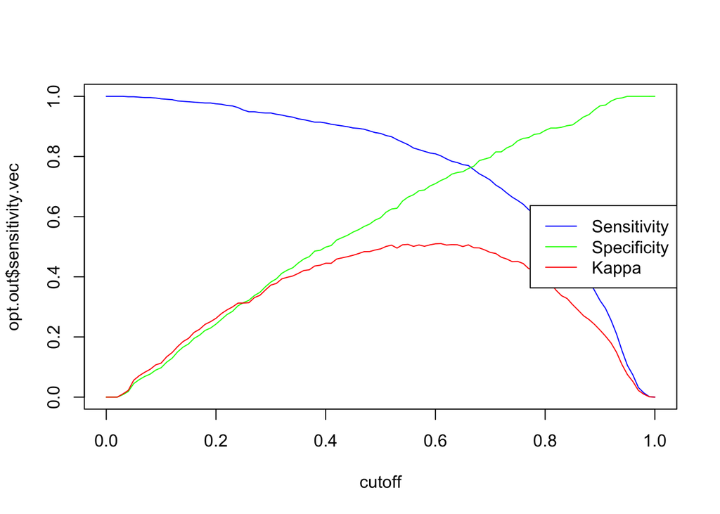

```r
logit.out1 <- opt.cut.gen(logit1, valid1)
opt.cut.plot(logit.out1)
```

```r
#optimal by kappa score
logit.out1$cutoff[which.max(logit.out1$kappa.vec)]
```

```
## [1] 0.61
```

```r
#optimal by sensitivity/specificity balance
logit.out1$cutoff[which.min(logit.out1$ssdiff.vec)]
```

```
## [1] 0.66
```

Final full logistic model fit to the combo of train and validation data.

```r
set.seed(123)
logit1.final <- glm(oldgen ~., data = all.train1, family = "binomial")
summary(logit1.final)
```

```
##
## Call:
## glm(formula = oldgen ~ ., family = "binomial", data = all.train1)
##
## Deviance Residuals:
##     Min       1Q   Median       3Q      Max
## -2.9689  -0.7651   0.3927   0.7123   2.8344
##
## Coefficients:
##                    Estimate Std. Error z value Pr(>|z|)
## (Intercept)       0.7830317  0.5708490   1.372 0.170158
## popularity       -0.0789437  0.0022892 -34.485  < 2e-16 ***
## duration          0.5121910  0.0650874   7.869 3.57e-15 ***
## acousticness     -0.8822530  0.1961078  -4.499 6.83e-06 ***
## danceability     -0.6653079  0.3371238  -1.973 0.048441 *
## energy           -0.5365435  0.3878817  -1.383 0.166583
## instrumentalness -2.4711501  0.3976516  -6.214 5.15e-10 ***
## key1              0.4146176  0.1235416   3.356 0.000791 ***
## key2             -0.0018795  0.1277455  -0.015 0.988261
## key3             -0.1485926  0.2005722  -0.741 0.458789
## key4             -0.2800836  0.1627272  -1.721 0.085217 .
## key5              0.2173409  0.1487580   1.461 0.144005
## key6              0.2796935  0.1473201   1.899 0.057625 .
## key7              0.1606723  0.1198348   1.341 0.179991
## key8              0.1850034  0.1368249   1.352 0.176338
## key9             -0.0055223  0.1489946  -0.037 0.970434
## key10             0.0713479  0.1781632   0.400 0.688815
## key11             0.0935255  0.1537171   0.608 0.542905
## loudness         -0.1537432  0.0268960  -5.716 1.09e-08 ***
## speechiness      -0.7920192  0.5616476  -1.410 0.158489
## tempo            -0.0001812  0.0012661  -0.143 0.886173
## valence           0.7418336  0.2024359   3.665 0.000248 ***
## ---
## Signif. codes:  0 '***' 0.001 '**' 0.01 '*' 0.05 '.' 0.1 ' ' 1
##
## (Dispersion parameter for binomial family taken to be 1)
##
##     Null deviance: 8158.1  on 6237  degrees of freedom
## Residual deviance: 5892.1  on 6216  degrees of freedom
## AIC: 5936.1
##
## Number of Fisher Scoring iterations: 5
```

confusion matrix on the test data using standard cut off

```r
#get predicted probabilities for the test data
logit.test1.pred <- predict(logit1.final, newdata = test1, type = "response")
logit.test1.y <- ifelse(logit.test1.pred > 0.5, 1, 0) # using cutoff = 0.5
confusionMatrix(as.factor(logit.test1.y), as.factor(test1$oldgen),
                positive = "1")
```

```
## Confusion Matrix and Statistics
##
##           Reference
## Prediction   0   1
##          0 249  98
##          1 162 592
##
##                Accuracy : 0.7639
##                  95% CI : (0.7376, 0.7887)
##     No Information Rate : 0.6267
##     P-Value [Acc > NIR] : < 2.2e-16
##
##                   Kappa : 0.4789
##
##  Mcnemar's Test P-Value : 9.341e-05
##
##             Sensitivity : 0.8580
##             Specificity : 0.6058
##          Pos Pred Value : 0.7851
##          Neg Pred Value : 0.7176
##              Prevalence : 0.6267
##          Detection Rate : 0.5377
##    Detection Prevalence : 0.6848
##       Balanced Accuracy : 0.7319
##
##        'Positive' Class : 1
##
```

confusion matrix on the test data using optimal cutoff based on kappa

```r
#get predicted probabilities for the test data
logit.test1.pred <- predict(logit1.final, newdata = test1, type = "response")
logit.test1.y <- ifelse(logit.test1.pred > 0.61, 1, 0) # using cutoff = 0.61
confusionMatrix(as.factor(logit.test1.y), as.factor(test1$oldgen),
                positive = "1")
```

```
## Confusion Matrix and Statistics
##
##           Reference
## Prediction   0   1
##          0 293 143
##          1 118 547
##
##                Accuracy : 0.7629
##                  95% CI : (0.7367, 0.7878)
##     No Information Rate : 0.6267
##     P-Value [Acc > NIR] : <2e-16
##
##                   Kappa : 0.4995
##
##  Mcnemar's Test P-Value : 0.1374
##
##             Sensitivity : 0.7928
##             Specificity : 0.7129
##          Pos Pred Value : 0.8226
##          Neg Pred Value : 0.6720
##              Prevalence : 0.6267
##          Detection Rate : 0.4968
##    Detection Prevalence : 0.6040
##       Balanced Accuracy : 0.7528
##
##        'Positive' Class : 1
##
```

confusion matrix on the test data using optimal cutoff based on sensitivity/specificty balance

```r
#get predicted probabilities for the test data
logit.test1.pred <- predict(logit1.final, newdata = test1, type = "response")
logit.test1.y <- ifelse(logit.test1.pred > 0.66, 1, 0) # using cutoff = 0.66
confusionMatrix(as.factor(logit.test1.y), as.factor(test1$oldgen),
                positive = "1")
```

```
## Confusion Matrix and Statistics
##
##           Reference
## Prediction   0   1
##          0 316 172
##          1  95 518
##
##                Accuracy : 0.7575
##                  95% CI : (0.7311, 0.7825)
##     No Information Rate : 0.6267
##     P-Value [Acc > NIR] : < 2.2e-16
##
##                   Kappa : 0.5006
##
##  Mcnemar's Test P-Value : 3.301e-06
##
##             Sensitivity : 0.7507
##             Specificity : 0.7689
##          Pos Pred Value : 0.8450
##          Neg Pred Value : 0.6475
##              Prevalence : 0.6267
##          Detection Rate : 0.4705
##    Detection Prevalence : 0.5568
##       Balanced Accuracy : 0.7598
##
##        'Positive' Class : 1
##
```

### Variable Selection: Stepwise

stepwise

```r
set.seed(123)
logit1.none <- glm(oldgen ~ 1, data = train1, family = binomial)
step1 <- step(logit1.none,
                 list(lower=formula(logit1.none), upper = formula(logit1)),
                 direction = "both",
                 trace=0)
formula(step1)
```

```
## oldgen ~ popularity + duration + loudness + acousticness + instrumentalness +
##     valence + key + danceability
```

```r
summary(step1)
```

```
##
## Call:
## glm(formula = oldgen ~ popularity + duration + loudness + acousticness +
##     instrumentalness + valence + key + danceability, family = binomial,
##     data = train1)
##
## Deviance Residuals:
##     Min       1Q   Median       3Q      Max
## -2.9625  -0.7640   0.3891   0.7101   2.8603
##
## Coefficients:
##                   Estimate Std. Error z value Pr(>|z|)
## (Intercept)       0.174528   0.403868   0.432 0.665639
## popularity       -0.080283   0.002512 -31.958  < 2e-16 ***
## duration          0.498630   0.071939   6.931 4.17e-12 ***
## loudness         -0.169250   0.022608  -7.486 7.09e-14 ***
## acousticness     -0.705422   0.181524  -3.886 0.000102 ***
## instrumentalness -2.369217   0.466017  -5.084 3.70e-07 ***
## valence           0.645666   0.212511   3.038 0.002379 **
## key1              0.488374   0.135582   3.602 0.000316 ***
## key2              0.077569   0.140970   0.550 0.582149
## key3             -0.118963   0.224447  -0.530 0.596093
## key4             -0.112844   0.182502  -0.618 0.536367
## key5              0.271520   0.162560   1.670 0.094865 .
## key6              0.346110   0.161120   2.148 0.031702 *
## key7              0.200362   0.131369   1.525 0.127213
## key8              0.251743   0.151740   1.659 0.097108 .
## key9             -0.055155   0.164077  -0.336 0.736754
## key10             0.143506   0.195935   0.732 0.463914
## key11             0.235120   0.168610   1.394 0.163179
## danceability     -0.526138   0.356026  -1.478 0.139459
## ---
## Signif. codes:  0 '***' 0.001 '**' 0.01 '*' 0.05 '.' 0.1 ' ' 1
##
## (Dispersion parameter for binomial family taken to be 1)
##
##     Null deviance: 6738.9  on 5136  degrees of freedom
## Residual deviance: 4855.2  on 5118  degrees of freedom
## AIC: 4893.2
##
## Number of Fisher Scoring iterations: 5
```

confusion matrix on the training data:

```
step.train1.pred <- step1$fitted.values
step.train1.y <- ifelse(step.train1.pred > 0.5, 1, 0) # using cutoff = 0.5
confusionMatrix(as.factor(step.train1.y), as.factor(train1$oldgen),
                positive = "1")
```

find optimal cut off value

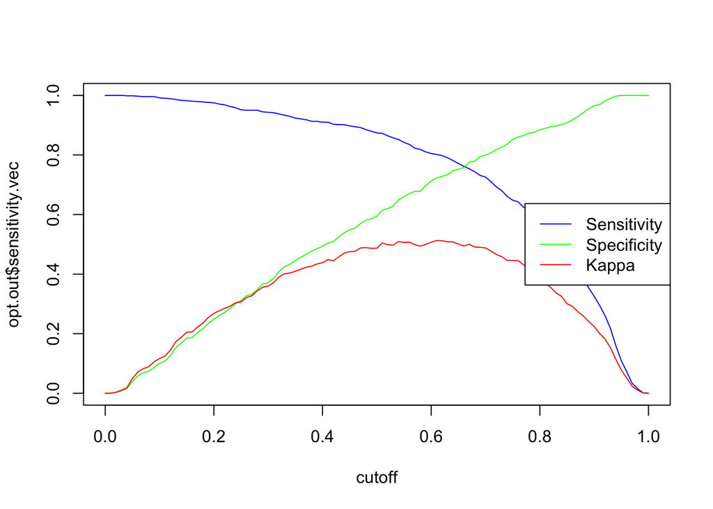

```r
step.out1 <- opt.cut.gen(step1, valid1)
opt.cut.plot(step.out1)
```

```r
#optimal by kappa score
step.out1$cutoff[which.max(step.out1$kappa.vec)]
```

```
## [1] 0.61
```

```r
#optimal by sensitivity/specificity balance
step.out1$cutoff[which.min(step.out1$ssdiff.vec)]
```

```
## [1] 0.66
```

final stepwise model

```r
set.seed(123)
logit1.none <- glm(oldgen ~ 1, data = all.train1, family = binomial)
step1.final <- step(logit1.none,
                 list(lower=formula(logit1.none), upper = formula(logit1)),
                 direction = "both",
                 trace=0)
formula(step1.final)
```

```
## oldgen ~ popularity + duration + loudness + instrumentalness +
##     acousticness + valence + key + danceability + speechiness
```

```r
summary(step1.final)
```

```
##
## Call:
## glm(formula = oldgen ~ popularity + duration + loudness + instrumentalness +
##     acousticness + valence + key + danceability + speechiness,
##     family = binomial, data = all.train1)
##
## Deviance Residuals:
##     Min       1Q   Median       3Q      Max
## -2.9929  -0.7636   0.3916   0.7108   2.8350
##
## Coefficients:
##                   Estimate Std. Error z value Pr(>|z|)
## (Intercept)       0.225784   0.367178   0.615 0.538610
## popularity       -0.078529   0.002266 -34.650  < 2e-16 ***
## duration          0.515308   0.065125   7.913 2.52e-15 ***
## loudness         -0.178352   0.020395  -8.745  < 2e-16 ***
## instrumentalness -2.516403   0.396780  -6.342 2.27e-10 ***
## acousticness     -0.739469   0.166784  -4.434 9.26e-06 ***
## valence           0.667741   0.194510   3.433 0.000597 ***
## key1              0.415093   0.123488   3.361 0.000775 ***
## key2             -0.001643   0.127686  -0.013 0.989736
## key3             -0.146881   0.200396  -0.733 0.463586
## key4             -0.279109   0.162751  -1.715 0.086356 .
## key5              0.222002   0.148690   1.493 0.135425
## key6              0.276443   0.147164   1.878 0.060317 .
## key7              0.162392   0.119805   1.355 0.175269
## key8              0.187019   0.136815   1.367 0.171640
## key9             -0.002166   0.148954  -0.015 0.988400
## key10             0.071686   0.178289   0.402 0.687626
## key11             0.094143   0.153573   0.613 0.539865
## danceability     -0.632472   0.322859  -1.959 0.050116 .
## speechiness      -0.980171   0.541930  -1.809 0.070503 .
## ---
## Signif. codes:  0 '***' 0.001 '**' 0.01 '*' 0.05 '.' 0.1 ' ' 1
##
## (Dispersion parameter for binomial family taken to be 1)
##
##     Null deviance: 8158.1  on 6237  degrees of freedom
## Residual deviance: 5894.0  on 6218  degrees of freedom
## AIC: 5934
##
## Number of Fisher Scoring iterations: 5
```

predict and evaluate on test using standard cut off 0.5

```r
#get predicted probabilities for the test data
step.test1.pred <- predict(step1.final, newdata = test1, type = "response")
step.test1.y <- ifelse(step.test1.pred > 0.5, 1, 0) # using cutoff = 0.5
confusionMatrix(as.factor(step.test1.y), as.factor(test1$oldgen),
                positive = "1")
```

```
## Confusion Matrix and Statistics
##
##           Reference
## Prediction   0   1
##          0 251  97
##          1 160 593
##
##                Accuracy : 0.7666
##                  95% CI : (0.7404, 0.7913)
##     No Information Rate : 0.6267
##     P-Value [Acc > NIR] : < 2e-16
##
##                   Kappa : 0.4852
##
##  Mcnemar's Test P-Value : 0.00011
##
##             Sensitivity : 0.8594
##             Specificity : 0.6107
##          Pos Pred Value : 0.7875
##          Neg Pred Value : 0.7213
##              Prevalence : 0.6267
##          Detection Rate : 0.5386
##    Detection Prevalence : 0.6839
##       Balanced Accuracy : 0.7351
##
##        'Positive' Class : 1
##
```

predict and evaluate on test using optimal cut off 0.61 for highest kappa

```r
#get predicted probabilities for the test data
step.test1.pred <- predict(step1.final, newdata = test1, type = "response")
step.test1.y <- ifelse(step.test1.pred > 0.61, 1, 0) # using cutoff = 0.61
confusionMatrix(as.factor(step.test1.y), as.factor(test1$oldgen),
                positive = "1")
```

```
## Confusion Matrix and Statistics
##
##           Reference
## Prediction   0   1
##          0 292 147
##          1 119 543
##
##                Accuracy : 0.7584
##                  95% CI : (0.732, 0.7834)
##     No Information Rate : 0.6267
##     P-Value [Acc > NIR] : < 2e-16
##
##                   Kappa : 0.4907
##
##  Mcnemar's Test P-Value : 0.09783
##
##             Sensitivity : 0.7870
##             Specificity : 0.7105
##          Pos Pred Value : 0.8202
##          Neg Pred Value : 0.6651
##              Prevalence : 0.6267
##          Detection Rate : 0.4932
##    Detection Prevalence : 0.6013
##       Balanced Accuracy : 0.7487
##
##        'Positive' Class : 1
##
```

predict and evaluate on test using optimal cut off 0.66 for best sensitivity/specificity balance

```r
#get predicted probabilities for the test data
step.test1.pred <- predict(step1.final, newdata = test1, type = "response")
step.test1.y <- ifelse(step.test1.pred > 0.66, 1, 0) # using cutoff = 0.66
confusionMatrix(as.factor(step.test1.y), as.factor(test1$oldgen),
                positive = "1")
```

```
## Confusion Matrix and Statistics
##
##           Reference
## Prediction   0   1
##          0 317 174
##          1  94 516
##
##                Accuracy : 0.7566
##                  95% CI : (0.7301, 0.7817)
##     No Information Rate : 0.6267
##     P-Value [Acc > NIR] : < 2.2e-16
##
##                   Kappa : 0.4995
##
##  Mcnemar's Test P-Value : 1.395e-06
##
##             Sensitivity : 0.7478
##             Specificity : 0.7713
##          Pos Pred Value : 0.8459
##          Neg Pred Value : 0.6456
##              Prevalence : 0.6267
##          Detection Rate : 0.4687
##    Detection Prevalence : 0.5540
##       Balanced Accuracy : 0.7596
##
##        'Positive' Class : 1
##
```

### Variable Selection: Stepwise (10 fold CV)

step-wise 10 fold cross validation

```r
set.seed(123)
train_control <- trainControl(method = "cv",
                              number = 10)

# Fit K-fold CV model
bye3 <- capture.output(step1_kcv <- train(oldgen ~ ., data = train1, family = binomial(),
                 method = "glmStepAIC", trControl = train_control, verbose = FALSE))
```

```r
step1_kcv <- step1_kcv$finalModel
step1_kcv
```

```
##
## Call:  NULL
##
## Coefficients:
##      (Intercept)        popularity          duration      acousticness
##          0.16071          -0.08025           0.50004          -0.71613
##     danceability  instrumentalness              key1              key5
##         -0.50514          -2.35289           0.48389           0.26836
##             key6              key7              key8             key11
##          0.34242           0.19602           0.24828           0.23193
##         loudness           valence
##         -0.16904           0.64727
##
## Degrees of Freedom: 5136 Total (i.e. Null);  5123 Residual
## Null Deviance:       6739
## Residual Deviance: 4857  AIC: 4885
```

```
#get predicted probabilities for training data
step_kcv.pred1 <- predict(step1_kcv, newdata = key.dummy(test1), type = "response")
step_kcv.train1.y <- ifelse(step_kcv.train1.pred > 0.5, 1, 0) # using cutoff = 0.5
confusionMatrix(as.factor(step_kcv.train1.y), as.factor(train1$oldgen),
                positive = "1")
```

find optimal cut off value

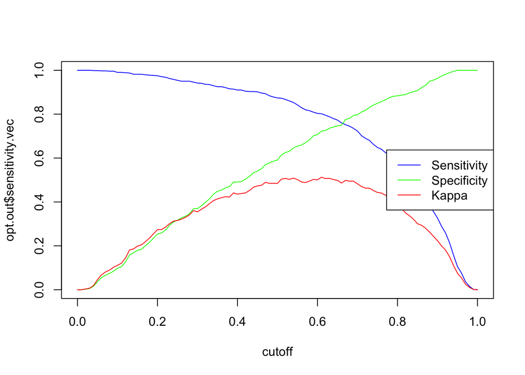

```r
step_kcv.out1 <- opt.cut.gen(step1_kcv, key.dummy(valid1))
opt.cut.plot(step_kcv.out1)
```

```r
#optimal by kappa score
step_kcv.out1$cutoff[which.max(step_kcv.out1$kappa.vec)]
```

```
## [1] 0.61
```

```r
#optimal by sensitivity/specificity balance
step_kcv.out1$cutoff[which.min(step_kcv.out1$ssdiff.vec)]
```

```
## [1] 0.66
```

Fit final model on combination of training and validation data

```r
set.seed(123)
# Fit K-fold CV model
bye4 <- capture.output(step1_kcv.final <- train(oldgen ~ ., data = all.train1, family = "binomial",
                 method = "glmStepAIC", trControl = train_control, verbose = FALSE))
```

```r
step1_kcv.final <- step1_kcv.final$finalModel
step1_kcv.final
```

```
##
## Call:  NULL
##
## Coefficients:
##      (Intercept)        popularity          duration      acousticness
##          0.23261          -0.07858           0.51341          -0.74269
##     danceability  instrumentalness              key1              key4
##         -0.62127          -2.52389           0.40636          -0.28657
##             key5              key6              key7              key8
##          0.21376           0.26814           0.15375           0.17878
##         loudness       speechiness           valence
##         -0.17846          -0.99190           0.67391
##
## Degrees of Freedom: 6237 Total (i.e. Null);  6223 Residual
## Null Deviance:       8158
## Residual Deviance: 5895  AIC: 5925
```

Get prediction and performance evaluation for standard cut off 0.5

```r
#get predicted probabilities for the test data
step_kcv.test1.pred <- predict(step1_kcv.final, newdata = key.dummy(test1), type = "response")
step_kcv.test1.y <- ifelse(step_kcv.test1.pred > 0.5, 1, 0) # using cutoff = 0.5
confusionMatrix(as.factor(step_kcv.test1.y), as.factor(test1$oldgen),
                positive = "1")
```

```
## Confusion Matrix and Statistics
##
##           Reference
## Prediction   0   1
##          0 251  96
##          1 160 594
##
##                Accuracy : 0.7675
##                  95% CI : (0.7414, 0.7921)
##     No Information Rate : 0.6267
##     P-Value [Acc > NIR] : < 2.2e-16
##
##                   Kappa : 0.4869
##
##  Mcnemar's Test P-Value : 8.233e-05
##
##             Sensitivity : 0.8609
##             Specificity : 0.6107
##          Pos Pred Value : 0.7878
##          Neg Pred Value : 0.7233
##              Prevalence : 0.6267
##          Detection Rate : 0.5395
##    Detection Prevalence : 0.6848
##       Balanced Accuracy : 0.7358
##
##        'Positive' Class : 1
##
```

Get prediction and performance evaluation for optimal cut off 0.61 for highest kappa

```r
#get predicted probabilities for the test data
step_kcv.test1.pred <- predict(step1_kcv.final, newdata = key.dummy(test1), type = "response")
step_kcv.test1.y <- ifelse(step_kcv.test1.pred > 0.61, 1, 0) # using cutoff = 0.61
confusionMatrix(as.factor(step_kcv.test1.y), as.factor(test1$oldgen),
                positive = "1")
```

```
## Confusion Matrix and Statistics
##
##           Reference
## Prediction   0   1
##          0 293 147
##          1 118 543
##
##                Accuracy : 0.7593
##                  95% CI : (0.7329, 0.7843)
##     No Information Rate : 0.6267
##     P-Value [Acc > NIR] : < 2e-16
##
##                   Kappa : 0.4928
##
##  Mcnemar's Test P-Value : 0.08543
##
##             Sensitivity : 0.7870
##             Specificity : 0.7129
##          Pos Pred Value : 0.8215
##          Neg Pred Value : 0.6659
##              Prevalence : 0.6267
##          Detection Rate : 0.4932
##    Detection Prevalence : 0.6004
##       Balanced Accuracy : 0.7499
##
##        'Positive' Class : 1
##
```

Get prediction and performance evaluation for optimal cut off 0.66 for best sensitivity/specificity balance

```r
#get predicted probabilities for the test data
step_kcv.test1.pred <- predict(step1_kcv.final, newdata = key.dummy(test1), type = "response")
step_kcv.test1.y <- ifelse(step_kcv.test1.pred > 0.66, 1, 0) # using cutoff = 0.66
confusionMatrix(as.factor(step_kcv.test1.y), as.factor(test1$oldgen),
                positive = "1")
```

```
## Confusion Matrix and Statistics
##
##           Reference
## Prediction   0   1
##          0 316 174
##          1  95 516
##
##                Accuracy : 0.7557
##                  95% CI : (0.7292, 0.7808)
##     No Information Rate : 0.6267
##     P-Value [Acc > NIR] : < 2.2e-16
##
##                   Kappa : 0.4974
##
##  Mcnemar's Test P-Value : 1.977e-06
##
##             Sensitivity : 0.7478
##             Specificity : 0.7689
##          Pos Pred Value : 0.8445
##          Neg Pred Value : 0.6449
##              Prevalence : 0.6267
##          Detection Rate : 0.4687
##    Detection Prevalence : 0.5550
##       Balanced Accuracy : 0.7583
##
##        'Positive' Class : 1
##
```

### Variable Selection: All possible regression

```r
set.seed(123)
glmulti.out1 <- glmulti(oldgen ~ ., data = train1,
                           level = 1,               # No interaction considered
            method = "h",            # Exhaustive approach
            crit = "aic",            # AIC as criteria
            confsetsize = 5,         # Keep 5 best models
            plotty = F, report = F,  # No plot or interim reports
            fitfunction = "glm",     # lm function
            family = binomial)       # binomial to run logistic regression
glmulti.out1@formulas
```

```
## [[1]]
## oldgen ~ 1 + key + popularity + duration + acousticness + danceability +
##     instrumentalness + loudness + valence
## <environment: 0x7f8680ceb0a8>
##
## [[2]]
## oldgen ~ 1 + key + popularity + duration + acousticness + instrumentalness +
##     loudness + valence
## <environment: 0x7f8680ceb0a8>
##
## [[3]]
## oldgen ~ 1 + key + popularity + duration + acousticness + danceability +
##     instrumentalness + loudness + speechiness + valence
## <environment: 0x7f8680ceb0a8>
##
## [[4]]
## oldgen ~ 1 + key + popularity + duration + acousticness + danceability +
##     energy + instrumentalness + loudness + valence
## <environment: 0x7f8680ceb0a8>
##
## [[5]]
## oldgen ~ 1 + key + popularity + duration + acousticness + instrumentalness +
##     loudness + speechiness + valence
## <environment: 0x7f8680ceb0a8>
```

view summary of top model

```r
summary(glmulti.out1@objects[[1]])
```

```
##
## Call:
## fitfunc(formula = as.formula(x), family = ..1, data = data)
##
## Deviance Residuals:
##     Min       1Q   Median       3Q      Max
## -2.9625  -0.7640   0.3891   0.7101   2.8603
##
## Coefficients:
##                   Estimate Std. Error z value Pr(>|z|)
## (Intercept)       0.174528   0.403868   0.432 0.665639
## key1              0.488374   0.135582   3.602 0.000316 ***
## key2              0.077569   0.140970   0.550 0.582149
## key3             -0.118963   0.224447  -0.530 0.596093
## key4             -0.112844   0.182502  -0.618 0.536367
## key5              0.271520   0.162560   1.670 0.094865 .
## key6              0.346110   0.161120   2.148 0.031702 *
## key7              0.200362   0.131369   1.525 0.127213
## key8              0.251743   0.151740   1.659 0.097108 .
## key9             -0.055155   0.164077  -0.336 0.736754
## key10             0.143506   0.195935   0.732 0.463914
## key11             0.235120   0.168610   1.394 0.163179
## popularity       -0.080283   0.002512 -31.958  < 2e-16 ***
## duration          0.498630   0.071939   6.931 4.17e-12 ***
## acousticness     -0.705422   0.181524  -3.886 0.000102 ***
## danceability     -0.526138   0.356026  -1.478 0.139459
## instrumentalness -2.369217   0.466017  -5.084 3.70e-07 ***
## loudness         -0.169250   0.022608  -7.486 7.09e-14 ***
## valence           0.645666   0.212511   3.038 0.002379 **
## ---
## Signif. codes:  0 '***' 0.001 '**' 0.01 '*' 0.05 '.' 0.1 ' ' 1
##
## (Dispersion parameter for binomial family taken to be 1)
##
##     Null deviance: 6738.9  on 5136  degrees of freedom
## Residual deviance: 4855.2  on 5118  degrees of freedom
## AIC: 4893.2
##
## Number of Fisher Scoring iterations: 5
```

Store model

```r
allreg.logit1 <- glmulti.out1@objects[[1]]
```

try fitting training data to results from all possible regression variable selection

```
#get predicted probabilities for training data
all.train1.pred <- allreg.logit1$fitted.values
all.train1.y <- ifelse(all.train1.pred > 0.5, 1, 0) # using cutoff = 0.5
confusionMatrix(as.factor(all.train1.y), as.factor(train1$oldgen),
                positive = "1")
```

find optimal cut off value

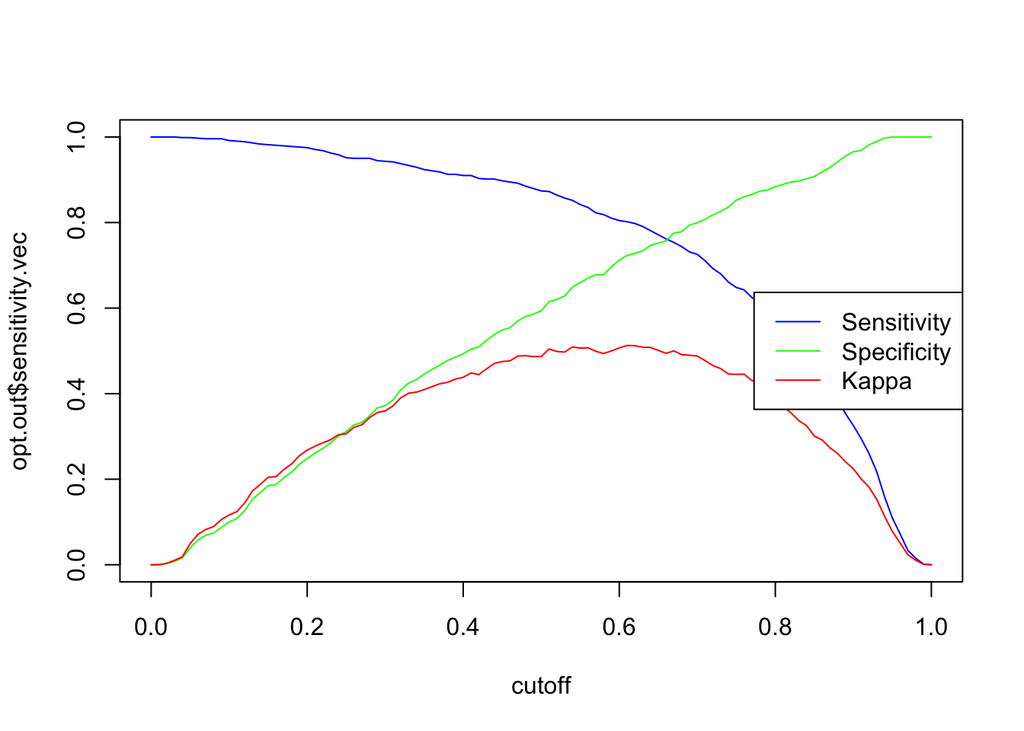

```r
allreg.out1 <- opt.cut.gen(allreg.logit1, valid1)
opt.cut.plot(allreg.out1)
```

```r
#optimal by kappa score
allreg.out1$cutoff[which.max(allreg.out1$kappa.vec)]
```

```
## [1] 0.61
```

```r
#optimal by sensitivity/specificity balance
allreg.out1$cutoff[which.min(allreg.out1$ssdiff.vec)]
```

```
## [1] 0.66
```

Fit final model on combo of train/validation data

```r
set.seed(123)
glmulti.out1.final <- glmulti(oldgen ~ ., data = all.train1,
                           level = 1,               # No interaction considered
            method = "h",            # Exhaustive approach
            crit = "aic",            # AIC as criteria
            confsetsize = 5,         # Keep 5 best models
            plotty = F, report = F,  # No plot or interim reports
            fitfunction = "glm",     # lm function
            family = binomial)       # binomial to run logistic regression
glmulti.out1.final@formulas
```

```
## [[1]]
## oldgen ~ 1 + key + popularity + duration + acousticness + danceability +
##     instrumentalness + loudness + speechiness + valence
## <environment: 0x7f867c278430>
##
## [[2]]
## oldgen ~ 1 + key + popularity + duration + acousticness + danceability +
##     energy + instrumentalness + loudness + speechiness + valence
## <environment: 0x7f867c278430>
##
## [[3]]
## oldgen ~ 1 + key + popularity + duration + acousticness + danceability +
##     energy + instrumentalness + loudness + valence
## <environment: 0x7f867c278430>
##
## [[4]]
## oldgen ~ 1 + key + popularity + duration + acousticness + danceability +
##     instrumentalness + loudness + valence
## <environment: 0x7f867c278430>
##
## [[5]]
## oldgen ~ 1 + key + popularity + duration + acousticness + instrumentalness +
##     loudness + speechiness + valence
## <environment: 0x7f867c278430>
```

```r
summary(glmulti.out1.final@objects[[1]])
```

```
##
## Call:
## fitfunc(formula = as.formula(x), family = ..1, data = data)
##
## Deviance Residuals:
##     Min       1Q   Median       3Q      Max
## -2.9929  -0.7636   0.3916   0.7108   2.8350
##
## Coefficients:
##                   Estimate Std. Error z value Pr(>|z|)
## (Intercept)       0.225784   0.367178   0.615 0.538610
## key1              0.415093   0.123488   3.361 0.000775 ***
## key2             -0.001643   0.127686  -0.013 0.989736
## key3             -0.146881   0.200396  -0.733 0.463586
## key4             -0.279109   0.162751  -1.715 0.086356 .
## key5              0.222002   0.148690   1.493 0.135425
## key6              0.276443   0.147164   1.878 0.060317 .
## key7              0.162392   0.119805   1.355 0.175269
## key8              0.187019   0.136815   1.367 0.171640
## key9             -0.002166   0.148954  -0.015 0.988400
## key10             0.071686   0.178289   0.402 0.687626
## key11             0.094143   0.153573   0.613 0.539865
## popularity       -0.078529   0.002266 -34.650  < 2e-16 ***
## duration          0.515308   0.065125   7.913 2.52e-15 ***
## acousticness     -0.739469   0.166784  -4.434 9.26e-06 ***
## danceability     -0.632472   0.322859  -1.959 0.050116 .
## instrumentalness -2.516403   0.396780  -6.342 2.27e-10 ***
## loudness         -0.178352   0.020395  -8.745  < 2e-16 ***
## speechiness      -0.980171   0.541930  -1.809 0.070503 .
## valence           0.667741   0.194510   3.433 0.000597 ***
## ---
## Signif. codes:  0 '***' 0.001 '**' 0.01 '*' 0.05 '.' 0.1 ' ' 1
##
## (Dispersion parameter for binomial family taken to be 1)
##
##     Null deviance: 8158.1  on 6237  degrees of freedom
## Residual deviance: 5894.0  on 6218  degrees of freedom
## AIC: 5934
##
## Number of Fisher Scoring iterations: 5
```

```r
allreg.logit1.final <- glmulti.out1.final@objects[[1]]
```

```r
#get predicted probabilities for the test data
all.test1.pred <- predict(allreg.logit1.final, newdata = test1, type = "response")
all.test1.y <- ifelse(all.test1.pred > 0.5, 1, 0) # using cutoff = 0.5
confusionMatrix(as.factor(all.test1.y), as.factor(test1$oldgen),
                positive = "1")
```

```
## Confusion Matrix and Statistics
##
##           Reference
## Prediction   0   1
##          0 251  97
##          1 160 593
##
##                Accuracy : 0.7666
##                  95% CI : (0.7404, 0.7913)
##     No Information Rate : 0.6267
##     P-Value [Acc > NIR] : < 2e-16
##
##                   Kappa : 0.4852
##
##  Mcnemar's Test P-Value : 0.00011
##
##             Sensitivity : 0.8594
##             Specificity : 0.6107
##          Pos Pred Value : 0.7875
##          Neg Pred Value : 0.7213
##              Prevalence : 0.6267
##          Detection Rate : 0.5386
##    Detection Prevalence : 0.6839
##       Balanced Accuracy : 0.7351
##
##        'Positive' Class : 1
##
```

```r
#get predicted probabilities for the test data
all.test1.pred <- predict(allreg.logit1.final, newdata = test1, type = "response")
all.test1.y <- ifelse(all.test1.pred > 0.61, 1, 0) # using cutoff = 0.61
confusionMatrix(as.factor(all.test1.y), as.factor(test1$oldgen),
                positive = "1")
```

```
## Confusion Matrix and Statistics
##
##           Reference
## Prediction   0   1
##          0 292 147
##          1 119 543
##
##                Accuracy : 0.7584
##                  95% CI : (0.732, 0.7834)
##     No Information Rate : 0.6267
##     P-Value [Acc > NIR] : < 2e-16
##
##                   Kappa : 0.4907
##
##  Mcnemar's Test P-Value : 0.09783
##
##             Sensitivity : 0.7870
##             Specificity : 0.7105
##          Pos Pred Value : 0.8202
##          Neg Pred Value : 0.6651
##              Prevalence : 0.6267
##          Detection Rate : 0.4932
##    Detection Prevalence : 0.6013
##       Balanced Accuracy : 0.7487
##
##        'Positive' Class : 1
##
```

```r
#get predicted probabilities for the test data
all.test1.pred <- predict(allreg.logit1.final, newdata = test1, type = "response")
all.test1.y <- ifelse(all.test1.pred > 0.66, 1, 0) # using cutoff = 0.66
confusionMatrix(as.factor(all.test1.y), as.factor(test1$oldgen),
                positive = "1")
```

```
## Confusion Matrix and Statistics
##
##           Reference
## Prediction   0   1
##          0 317 174
##          1  94 516
##
##                Accuracy : 0.7566
##                  95% CI : (0.7301, 0.7817)
##     No Information Rate : 0.6267
##     P-Value [Acc > NIR] : < 2.2e-16
##
##                   Kappa : 0.4995
##
##  Mcnemar's Test P-Value : 1.395e-06
##
##             Sensitivity : 0.7478
##             Specificity : 0.7713
##          Pos Pred Value : 0.8459
##          Neg Pred Value : 0.6456
##              Prevalence : 0.6267
##          Detection Rate : 0.4687
##    Detection Prevalence : 0.5540
##       Balanced Accuracy : 0.7596
##
##        'Positive' Class : 1
##
```

### Regularized Regression: Ridge 10 fold Cross Validation

```r
set.seed(123)
ridge1 <- train(oldgen ~ ., data = train1, method = "glmnet",
                      family = "binomial", trControl = train_control,
                      tuneGrid = expand.grid(alpha = 0,lambda = seq(0.001,0.1,by = 0.001)))
#best tuning parameter
ridge1$bestTune
```

```
##    alpha lambda
## 42     0  0.042
```

```r
ridge1.model <- coef(ridge1$finalModel, ridge1$bestTune$lambda)
ridge1.model
```

```
## 22 x 1 sparse Matrix of class "dgCMatrix"
##                             1
## (Intercept)       0.445728256
## popularity       -0.059215594
## duration          0.386121106
## acousticness     -0.479462650
## danceability     -0.238448937
## energy           -0.195512824
## instrumentalness -1.355725645
## key1              0.259759915
## key2             -0.032289936
## key3             -0.199478535
## key4             -0.143394637
## key5              0.127155237
## key6              0.175455360
## key7              0.047727115
## key8              0.084025996
## key9             -0.127574782
## key10             0.045439332
## key11             0.071827929
## loudness         -0.110057695
## speechiness      -0.808011289
## tempo            -0.000153871
## valence           0.461220137
```

Search for best cutoff using validation set

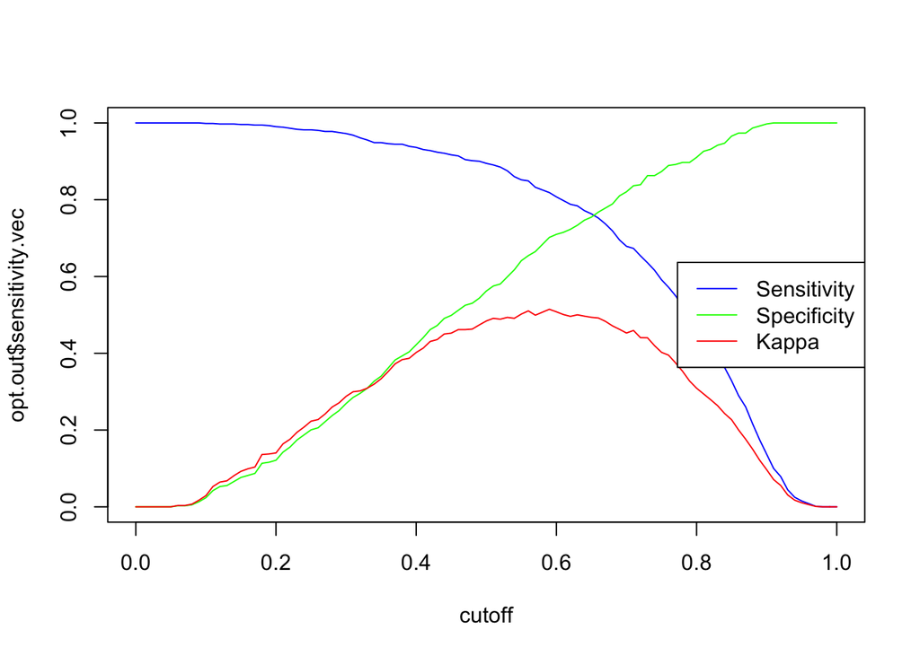

```r
ridge1.out <- reg.opt.cut.gen(ridge1, valid1)
opt.cut.plot(ridge1.out)
```

```r
# cut off by kappa
ridge1.out$cutoff[which.max(ridge1.out$kappa.vec)]
```

```
## [1] 0.59
```

```r
ridge1.out$cutoff[which.min(ridge1.out$ssdiff.vec)]
```

```
## [1] 0.65
```

create final model

```r
set.seed(123)
ridge1.final <- train(oldgen ~ ., data = all.train1, method = "glmnet",
                      family = "binomial", trControl = train_control,
                      tuneGrid = expand.grid(alpha = 0,lambda = seq(0.001,0.1,by = 0.001)))
#best tuning parameter
ridge1.final$bestTune
```

```
##    alpha lambda
## 27     0  0.027
```

```r
ridge1.model.final <- coef(ridge1.final$finalModel, ridge1.final$bestTune$lambda)
ridge1.model.final
```

```
## 22 x 1 sparse Matrix of class "dgCMatrix"
##                              1
## (Intercept)       0.5541294380
## popularity       -0.0638253523
## duration          0.4333491431
## acousticness     -0.5784136667
## danceability     -0.3727581875
## energy           -0.3315844407
## instrumentalness -1.6859329603
## key1              0.2677400963
## key2             -0.0619660708
## key3             -0.2041359260
## key4             -0.2614129971
## key5              0.1272764276
## key6              0.1697868773
## key7              0.0626617699
## key8              0.0784620329
## key9             -0.0655555202
## key10             0.0263336798
## key11             0.0150609098
## loudness         -0.1204054644
## speechiness      -0.9071621548
## tempo            -0.0000536344
## valence           0.5205531950
```

predict and evaluate on the test set where cutoff is at 0.5

```r
prob.ridge1 <- predict(ridge1.final, s = ridge1.final$bestTune, test1, type = "prob")
pred.ridge1 <- ifelse(prob.ridge1[,2] > 0.50, 1, 0) # using cutoff = 0.5
confusionMatrix(as.factor(pred.ridge1), as.factor(test1$oldgen),
                positive = "1")
```

```
## Confusion Matrix and Statistics
##
##           Reference
## Prediction   0   1
##          0 239  87
##          1 172 603
##
##                Accuracy : 0.7648
##                  95% CI : (0.7386, 0.7895)
##     No Information Rate : 0.6267
##     P-Value [Acc > NIR] : < 2.2e-16
##
##                   Kappa : 0.4753
##
##  Mcnemar's Test P-Value : 1.794e-07
##
##             Sensitivity : 0.8739
##             Specificity : 0.5815
##          Pos Pred Value : 0.7781
##          Neg Pred Value : 0.7331
##              Prevalence : 0.6267
##          Detection Rate : 0.5477
##    Detection Prevalence : 0.7039
##       Balanced Accuracy : 0.7277
##
##        'Positive' Class : 1
##
```

predict and evaluate on the test set where cutoff is at 0.59 corresponding to optimal kappa

```r
prob.ridge1 <- predict(ridge1.final, s = ridge1.final$bestTune, test1, type = "prob")
pred.ridge1 <- ifelse(prob.ridge1[,2] > 0.59, 1, 0) # using cutoff = 0.59
confusionMatrix(as.factor(pred.ridge1), as.factor(test1$oldgen),
                positive = "1")
```

```
## Confusion Matrix and Statistics
##
##           Reference
## Prediction   0   1
##          0 283 128
##          1 128 562
##
##                Accuracy : 0.7675
##                  95% CI : (0.7414, 0.7921)
##     No Information Rate : 0.6267
##     P-Value [Acc > NIR] : <2e-16
##
##                   Kappa : 0.5031
##
##  Mcnemar's Test P-Value : 1
##
##             Sensitivity : 0.8145
##             Specificity : 0.6886
##          Pos Pred Value : 0.8145
##          Neg Pred Value : 0.6886
##              Prevalence : 0.6267
##          Detection Rate : 0.5104
##    Detection Prevalence : 0.6267
##       Balanced Accuracy : 0.7515
##
##        'Positive' Class : 1
##
```

predict and evaluate on the test set where cutoff is at 0.65 corresponding to optimal balance of sensitivity and specificity

```r
prob.ridge1 <- predict(ridge1.final, s = ridge1.final$bestTune, test1, type = "prob")
pred.ridge1 <- ifelse(prob.ridge1[,2] > 0.65, 1, 0) # using cutoff = 0.65
confusionMatrix(as.factor(pred.ridge1), as.factor(test1$oldgen),
                positive = "1")
```

```
## Confusion Matrix and Statistics
##
##           Reference
## Prediction   0   1
##          0 315 172
##          1  96 518
##
##                Accuracy : 0.7566
##                  95% CI : (0.7301, 0.7817)
##     No Information Rate : 0.6267
##     P-Value [Acc > NIR] : < 2.2e-16
##
##                   Kappa : 0.4985
##
##  Mcnemar's Test P-Value : 4.62e-06
##
##             Sensitivity : 0.7507
##             Specificity : 0.7664
##          Pos Pred Value : 0.8436
##          Neg Pred Value : 0.6468
##              Prevalence : 0.6267
##          Detection Rate : 0.4705
##    Detection Prevalence : 0.5577
##       Balanced Accuracy : 0.7586
##
##        'Positive' Class : 1
##
```

### Regularized Regression: Lasso 10 fold Cross Validation

```r
set.seed(123)
lasso1 <- train(oldgen ~ ., data = train1, method = "glmnet",
                      family = "binomial", trControl = train_control,
                      tuneGrid = expand.grid(alpha = 1,lambda = seq(0.001,0.1,by = 0.001)))
# best parameter
lasso1$bestTune
```

```
##    alpha lambda
## 10     1   0.01
```

```r
# best coefficient
lasso1.model <- coef(lasso1$finalModel, lasso1$bestTune$lambda)
lasso1.model
```

```
## 22 x 1 sparse Matrix of class "dgCMatrix"
##                             1
## (Intercept)       0.927911611
## popularity       -0.075011921
## duration          0.354362750
## acousticness     -0.194746828
## danceability      .
## energy            .
## instrumentalness -1.168936964
## key1              0.172825775
## key2              .
## key3              .
## key4             -0.001909741
## key5              .
## key6              .
## key7              .
## key8              .
## key9              .
## key10             .
## key11             .
## loudness         -0.080633387
## speechiness       .
## tempo             .
## valence           0.098005119
```

Search for best cutoff using validation set

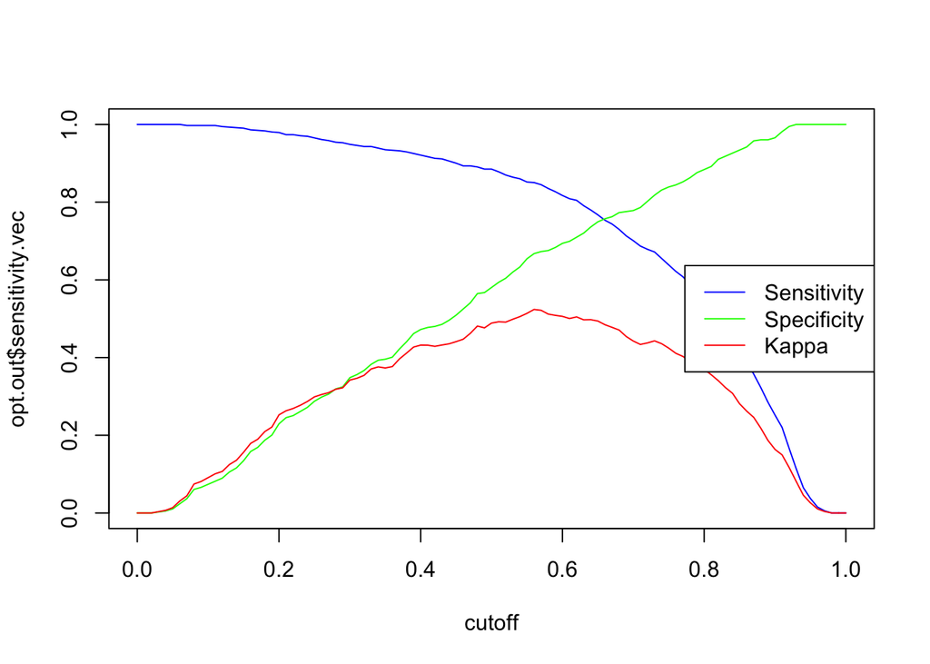

```r
lasso1.out <- reg.opt.cut.gen(lasso1, valid1)
opt.cut.plot(lasso1.out)
```

```r
# cut off by kappa
lasso1.out$cutoff[which.max(lasso1.out$kappa.vec)]
```

```
## [1] 0.56
```

```r
lasso1.out$cutoff[which.min(lasso1.out$ssdiff.vec)]
```

```
## [1] 0.66
```

create final model

```r
set.seed(123)
lasso1.final <- train(oldgen ~ ., data = train1, method = "glmnet",
                      family = "binomial", trControl = train_control,
                      tuneGrid = expand.grid(alpha = 1,lambda = seq(0.001,0.1,by = 0.001)))
# best parameter
lasso1.final$bestTune
```

```
##    alpha lambda
## 10     1   0.01
```

```r
# best coefficient
lasso1.model.final <- coef(lasso1.final$finalModel, lasso1.final$bestTune$lambda)
lasso1.model.final
```

```
## 22 x 1 sparse Matrix of class "dgCMatrix"
##                             1
## (Intercept)       0.927911611
## popularity       -0.075011921
## duration          0.354362750
## acousticness     -0.194746828
## danceability      .
## energy            .
## instrumentalness -1.168936964
## key1              0.172825775
## key2              .
## key3              .
## key4             -0.001909741
## key5              .
## key6              .
## key7              .
## key8              .
## key9              .
## key10             .
## key11             .
## loudness         -0.080633387
## speechiness       .
## tempo             .
## valence           0.098005119
```

predict and evaluate on the test set where cutoff is at 0.5

```r
prob.lasso1 <- predict(lasso1.final, s = lasso1.final$bestTune, test1, type = "prob")
pred.lasso1 <- ifelse(prob.lasso1[,2] > 0.50, 1, 0) # using cutoff = 0.5
confusionMatrix(as.factor(pred.lasso1), as.factor(test1$oldgen),
                positive = "1")
```

```
## Confusion Matrix and Statistics
##
##           Reference
## Prediction   0   1
##          0 245  87
##          1 166 603
##
##                Accuracy : 0.7702
##                  95% CI : (0.7442, 0.7948)
##     No Information Rate : 0.6267
##     P-Value [Acc > NIR] : < 2.2e-16
##
##                   Kappa : 0.489
##
##  Mcnemar's Test P-Value : 9.399e-07
##
##             Sensitivity : 0.8739
##             Specificity : 0.5961
##          Pos Pred Value : 0.7841
##          Neg Pred Value : 0.7380
##              Prevalence : 0.6267
##          Detection Rate : 0.5477
##    Detection Prevalence : 0.6985
##       Balanced Accuracy : 0.7350
##
##        'Positive' Class : 1
##
```

predict and evaluate on the test set where cutoff is at 0.56 corresponding to optimal kappa

```r
prob.lasso1 <- predict(lasso1.final, s = lasso1.final$bestTune, test1, type = "prob")
pred.lasso1 <- ifelse(prob.lasso1[,2] > 0.56, 1, 0) # using cutoff = 0.56
confusionMatrix(as.factor(pred.lasso1), as.factor(test1$oldgen),
                positive = "1")
```

```
## Confusion Matrix and Statistics
##
##           Reference
## Prediction   0   1
##          0 271 108
##          1 140 582
##
##                Accuracy : 0.7748
##                  95% CI : (0.7489, 0.7991)
##     No Information Rate : 0.6267
##     P-Value [Acc > NIR] : < 2e-16
##
##                   Kappa : 0.5109
##
##  Mcnemar's Test P-Value : 0.04901
##
##             Sensitivity : 0.8435
##             Specificity : 0.6594
##          Pos Pred Value : 0.8061
##          Neg Pred Value : 0.7150
##              Prevalence : 0.6267
##          Detection Rate : 0.5286
##    Detection Prevalence : 0.6558
##       Balanced Accuracy : 0.7514
##
##        'Positive' Class : 1
##
```

predict and evaluate on the test set where cutoff is at 0.66 corresponding to optimal balance of sensitivity and specificity

```r
prob.lasso1 <- predict(lasso1.final, s = lasso1.final$bestTune, test1, type = "prob")
pred.lasso1 <- ifelse(prob.lasso1[,2] > 0.66, 1, 0) # using cutoff = 0.66
confusionMatrix(as.factor(pred.lasso1), as.factor(test1$oldgen),
                positive = "1")
```

```
## Confusion Matrix and Statistics
##
##           Reference
## Prediction   0   1
##          0 313 175
##          1  98 515
##
##                Accuracy : 0.752
##                  95% CI : (0.7254, 0.7773)
##     No Information Rate : 0.6267
##     P-Value [Acc > NIR] : < 2.2e-16
##
##                   Kappa : 0.4894
##
##  Mcnemar's Test P-Value : 4.23e-06
##
##             Sensitivity : 0.7464
##             Specificity : 0.7616
##          Pos Pred Value : 0.8401
##          Neg Pred Value : 0.6414
##              Prevalence : 0.6267
##          Detection Rate : 0.4678
##    Detection Prevalence : 0.5568
##       Balanced Accuracy : 0.7540
##
##        'Positive' Class : 1
##
```

### Regularized Regression: Elastic Net 10 fold Cross Validation

```r
set.seed(123)
enet1 <- train(oldgen ~ ., data = train1, method = "glmnet",
                      family = "binomial", trControl = train_control,
                      tuneGrid = expand.grid(alpha = seq(0,1,by = 0.05),lambda = seq(0.001,0.1,by = 0.001)))
# best parameter
enet1$bestTune
```

```
##      alpha lambda
## 1417   0.7  0.017
```

```r
# best coefficient
enet1.model <- coef(enet1$finalModel, enet1$bestTune$lambda)
enet1.model
```

```
## 22 x 1 sparse Matrix of class "dgCMatrix"
##                            1
## (Intercept)       1.01849587
## popularity       -0.07115338
## duration          0.32198320
## acousticness     -0.10713632
## danceability      .
## energy            .
## instrumentalness -0.82335391
## key1              0.13126880
## key2              .
## key3              .
## key4              .
## key5              .
## key6              .
## key7              .
## key8              .
## key9              .
## key10             .
## key11             .
## loudness         -0.06633357
## speechiness       .
## tempo             .
## valence           0.03358681
```

search for best cutoff with validation set

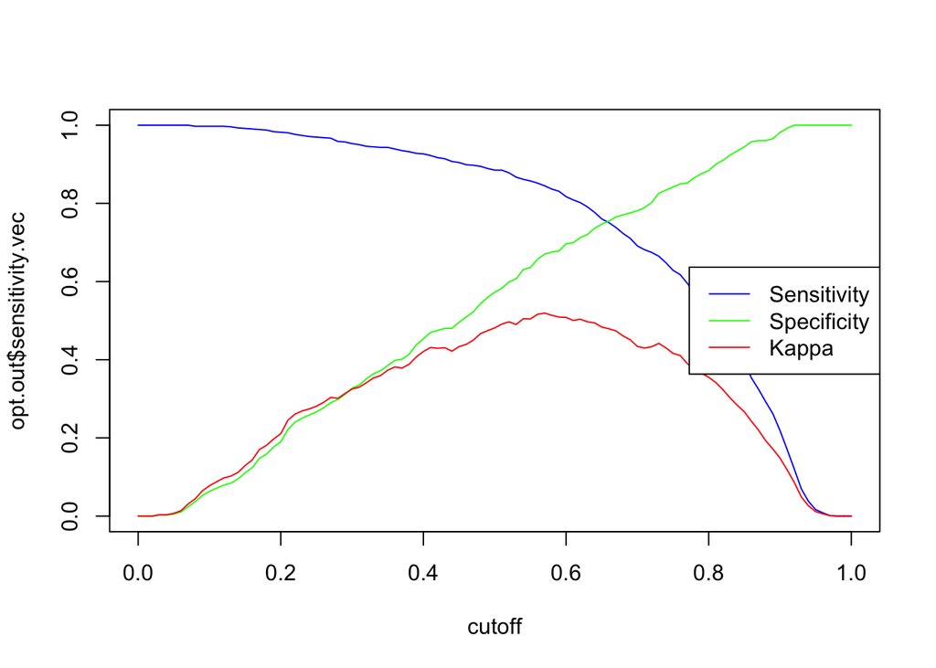

```r
enet1.out <- reg.opt.cut.gen(enet1, valid1)
opt.cut.plot(enet1.out)
```

```r
# cut off by kappa
enet1.out$cutoff[which.max(enet1.out$kappa.vec)]
```

```
## [1] 0.57
```

```r
enet1.out$cutoff[which.min(enet1.out$ssdiff.vec)]
```

```
## [1] 0.66
```

create final model on train and validation

```r
set.seed(123)
enet1.final <- train(oldgen ~ ., data = all.train1, method = "glmnet",
                      family = "binomial", trControl = train_control,
                      tuneGrid = expand.grid(alpha = seq(0,1,by = 0.05),lambda = seq(0.001,0.1,by = 0.001)))
# best parameter
enet1.final$bestTune
```

```
##      alpha lambda
## 1813   0.9  0.013
```

```r
# best coefficient
enet1.model.final <- coef(enet1.final$finalModel, enet1.final$bestTune$lambda)
enet1.model.final
```

```
## 22 x 1 sparse Matrix of class "dgCMatrix"
##                             1
## (Intercept)       0.915014097
## popularity       -0.072339884
## duration          0.360251539
## acousticness     -0.106398505
## danceability      .
## energy            .
## instrumentalness -1.081526677
## key1              0.116625900
## key2              .
## key3              .
## key4             -0.063111834
## key5              .
## key6              .
## key7              .
## key8              .
## key9              .
## key10             .
## key11             .
## loudness         -0.072654494
## speechiness       .
## tempo             .
## valence           0.009910263
```

predict and evaluate on the test set where cutoff is at 0.5

```r
prob.enet1 <- predict(enet1.final, s = enet1.final$bestTune, test1, type = "prob")
pred.enet1 <- ifelse(prob.enet1[,2] > 0.50, 1, 0) # using cutoff = 0.5
confusionMatrix(as.factor(pred.enet1), as.factor(test1$oldgen),
                positive = "1")
```

```
## Confusion Matrix and Statistics
##
##           Reference
## Prediction   0   1
##          0 240  86
##          1 171 604
##
##                Accuracy : 0.7666
##                  95% CI : (0.7404, 0.7913)
##     No Information Rate : 0.6267
##     P-Value [Acc > NIR] : < 2.2e-16
##
##                   Kappa : 0.4793
##
##  Mcnemar's Test P-Value : 1.608e-07
##
##             Sensitivity : 0.8754
##             Specificity : 0.5839
##          Pos Pred Value : 0.7794
##          Neg Pred Value : 0.7362
##              Prevalence : 0.6267
##          Detection Rate : 0.5486
##    Detection Prevalence : 0.7039
##       Balanced Accuracy : 0.7297
##
##        'Positive' Class : 1
##
```

predict and evaluate on the test set where cutoff is at 0.57 corresponding to optimal kappa

```r
prob.enet1 <- predict(enet1.final, s = enet1.final$bestTune, test1, type = "prob")
pred.enet1 <- ifelse(prob.enet1[,2] > 0.57, 1, 0) # using cutoff = 0.57
confusionMatrix(as.factor(pred.enet1), as.factor(test1$oldgen),
                positive = "1")
```

```
## Confusion Matrix and Statistics
##
##           Reference
## Prediction   0   1
##          0 273 110
##          1 138 580
##
##                Accuracy : 0.7748
##                  95% CI : (0.7489, 0.7991)
##     No Information Rate : 0.6267
##     P-Value [Acc > NIR] : < 2e-16
##
##                   Kappa : 0.5119
##
##  Mcnemar's Test P-Value : 0.08644
##
##             Sensitivity : 0.8406
##             Specificity : 0.6642
##          Pos Pred Value : 0.8078
##          Neg Pred Value : 0.7128
##              Prevalence : 0.6267
##          Detection Rate : 0.5268
##    Detection Prevalence : 0.6521
##       Balanced Accuracy : 0.7524
##
##        'Positive' Class : 1
##
```

predict and evaluate on the test set where cutoff is at 0.66 corresponding to optimal balance of sensitivity and specificity

```r
prob.enet1 <- predict(enet1.final, s = enet1.final$bestTune, test1, type = "prob")
pred.enet1 <- ifelse(prob.enet1[,2] > 0.66, 1, 0) # using cutoff = 0.66
confusionMatrix(as.factor(pred.enet1), as.factor(test1$oldgen),
                positive = "1")
```

```
## Confusion Matrix and Statistics
##
##           Reference
## Prediction   0   1
##          0 313 175
##          1  98 515
##
##                Accuracy : 0.752
##                  95% CI : (0.7254, 0.7773)
##     No Information Rate : 0.6267
##     P-Value [Acc > NIR] : < 2.2e-16
##
##                   Kappa : 0.4894
##
##  Mcnemar's Test P-Value : 4.23e-06
##
##             Sensitivity : 0.7464
##             Specificity : 0.7616
##          Pos Pred Value : 0.8401
##          Neg Pred Value : 0.6414
##              Prevalence : 0.6267
##          Detection Rate : 0.4678
##    Detection Prevalence : 0.5568
##       Balanced Accuracy : 0.7540
##
##        'Positive' Class : 1
##
```

### Deciding on the best model for Mode 1 songs

Full Logistic model
$$log(\frac{\hat \pi}{1 - \hat \pi}) = 0.783 - 0.079{Popularity} + 0.512{Duration} - 0.882{Acousticness} - 0.665{Danceability}
\\ - 0.537{Energy} - 2.471{Instrumentalness} + 0.415{Key1} - 0.002{Key2}
\\ - 0.149{Key3} - 0.280{Key4} + 0.217{Key5} + 0.280{Key6} + 0.161{Key7}
\\ + 0.185{Key8} - 0.006{Key9} + 0.071{Key10} + 0.094{Key11} - 0.154{Loudness}
\\ - 0.792{Speechiness} - 0.0002{Tempo} + 0.742{Valence}$$

Stepwise Logistic Model Compared to the full model, the stepwise logistic model does not have Tempo or Energy in the model
$$log(\frac{\hat \pi}{1 - \hat \pi}) = 0.226 - 0.079{Popularity} + 0.515Duration - 0.739{Acousticness} - 0.632{Danceability}
\\ - 2.516{Instrumentalness} + 0.415{Key1} - 0.002{Key2}
\\ - 0.147{Key3} - 0.279{Key4} + 0.222{Key5} + 0.276{Key6} + 0.162{Key7}
\\ + 0.187{Key8} - 0.002{Key9} + 0.072{Key10} + 0.094{Key11} - 0.178{Loudness}
\\ - 0.980{Speechiness} + 0.668{Valence}$$

Stepwise 10kcv Logistic Model Energy, Key2, Key3, Key9, Key10, Key11 and Tempo not included. Code has issues running this model through prediction due to the dummy variables :(
$$log(\frac{\hat \pi}{1 - \hat \pi}) = 0.233 - 0.079{Popularity} + 0.513{Duration} - 0.743{Acousticness} - 0.621{Danceability}
\\ - 2.524{Instrumentalness} + 0.406{Key1} - 0.287{Key4} + 0.214{Key5}
\\ + 0.268{Key6} + 0.154{Key7} + 0.179{Key8} - 0.178{Loudness}
\\ - 0.992{Speechiness} + 0.674{Valence}$$

All Possible Regressions Model Compared to the Full model, the one resulting from All possible Regressions omits Energy and Tempo
$$log(\frac{\hat \pi}{1 - \hat \pi}) = 0.226 - 0.079{Popularity} + 0.515Duration - 0.739{Acousticness} - 0.632{Danceability}
\\ - 2.516{Instrumentalness} + 0.415{Key1} - 0.002{Key2}
\\ - 0.147{Key3} - 0.279{Key4} + 0.222{Key5} + 0.276{Key6} + 0.162{Key7}
\\ + 0.187{Key8} - 0.002{Key9} + 0.072{Key10} + 0.094{Key11} - 0.178{Loudness}
\\ - 0.980{Speechiness} + 0.668{Valence}$$

Ridge 10 Fold Cross Validation Logistic model
$$log(\frac{\hat \pi}{1 - \hat \pi}) = 0.554 - 0.064{Popularity} + 0.433{Duration} - 0.578{Acousticness} - 0.373{Danceability}
\\ - 0.332{Energy} - 1.686{Instrumentalness} + 0.268{Key1} - 0.062{Key2}
\\ - 0.204{Key3} - 0.261{Key4} + 0.127{Key5} + 0.170{Key6} + 0.063{Key7}
\\ + 0.078{Key8} - 0.065{Key9} + 0.026{Key10} + 0.015{Key11} - 0.120{Loudness}
\\ - 0.907{Speechiness} - 0.0001{Tempo} + 0.521{Valence}$$

Lasso 10 Fold Cross Validation Logistic model Compared to the full logistic model the lasso model does not include the variables Danceability, Energy, Key2, Key3, Key5 - Key11, Speechiness, and Tempo.
$$log(\frac{\hat \pi}{1 - \hat \pi}) = 0.928 - 0.075{Popularity} + 0.354{Duration} - 0.195{Acousticness}
\\ - 1.169{Instrumentalness} + 0.173{Key1} - 0.002{Key4} - 0.081{Loudness} + 0.098{Valence}$$

Elastic Net 10 Fold Cross Validation Logistic model Compared to the full logistic model the lasso model does not include the variables Danceability, Energy, Key2, Key3, Key5 - Key11, Speechiness, and Tempo.
$$log(\frac{\hat \pi}{1 - \hat \pi}) = 0.915 - 0.072{Popularity} + 0.360{Duration} - 0.106{Acousticness}
\\ - 1.08{Instrumentalness} + 0.117{Key1} - 0.063{Key4} - 0.073{Loudness} + 0.010{Valence}$$

Performance metrics

```r
mode1.results <- data.frame(Model = c("Full", "Step", "Step 10CV", "AllReg", "Ridge 10CV", "Lasso 10CV", "ElasticNet 10CV"),
                            cutoff = c(0.66, 0.66, 0.66, 0.66, 0.65, 0.66, 0.66), #Best balance between sensitivity and specificity
                            AIC = c(5936.1, 5934, 5925, 5934, NA, NA, NA),
                            Accuracy = c(0.7575, 0.7566, 0.7557, 0.7566, 0.7566, 0.7520, 0.752),
                            Kappa = c(0.5006, 0.4995, 0.4974, 0.4995, 0.4985, 0.4894, 0.4894),
                            Sensitivity = c(0.7507, 0.7478, 0.7478, 0.7478, 0.7507, 0.7464, 0.7464),
                            Specificity = c(0.7689, 0.7713, 0.7689, 0.7713, 0.7664, 0.7616, 0.7616))
mode1.results
```

```
##             Model cutoff    AIC Accuracy  Kappa Sensitivity Specificity
## 1            Full   0.66 5936.1   0.7575 0.5006      0.7507      0.7689
## 2            Step   0.66 5934.0   0.7566 0.4995      0.7478      0.7713
## 3       Step 10CV   0.66 5925.0   0.7557 0.4974      0.7478      0.7689
## 4          AllReg   0.66 5934.0   0.7566 0.4995      0.7478      0.7713
## 5      Ridge 10CV   0.65     NA   0.7566 0.4985      0.7507      0.7664
## 6      Lasso 10CV   0.66     NA   0.7520 0.4894      0.7464      0.7616
## 7 ElasticNet 10CV   0.66     NA   0.7520 0.4894      0.7464      0.7616
```